# OBJETIVO 4

Sergio Ortiz

2025-05-22

## Introducción

En el marco del análisis integral de la **calidad ambiental de la ciudad de Valencia**, este bloque de trabajo se centra en la **contribución del parque edificatorio a las emisiones de CO₂** y en cómo dicho comportamiento energético se relaciona con otros factores urbanos (contaminantes atmosféricos, tráfico y condiciones meteorológicas).

### Objetivos específicos del estudio

1. **Depurar y enriquecer** la base de datos de certificados energéticos para obtener indicadores clave, entre ellos:
   - Intensidad de emisiones (kg CO₂ / m²·año)
   - Antigüedad de los edificios
   - Tipología y uso predominante
2. **Estudio preliminar de los códigos postales**
3. **Geocodificar** cada inmueble y **agruparlos por clústeres** espaciales que permitan identificar patrones de emisiones a escala de barrio (centro histórico, zonas industriales, área marítima, etc.).
4. **Relacionar** los clústeres edificatorios con:
   - Niveles de contaminantes (NO₂, PM₂.₅…) registrados en las estaciones de calidad del aire.
   - **Tráfico** (intensidad media diaria) en la red principal.
5. **Evaluar la influencia** de variables como uso, antigüedad o contexto urbano en las emisiones y en la calidad del aire local, con el fin de proponer estrategias de mitigación y renovación energética.

> Este documento aborda el **Paso 1 – Limpieza y preprocesado** del CSV de certificados, dejando los datos listos para la geocodificación y los análisis posteriores.

Los datos que se han analizado provienen de la página web del [**IVACE**](https://gceedadesobertes.aven.es/dadesobertes/), se ha descargado los csv de los registros de los **Certificado de Eficiencia Energéticos(CEE)** desde 2013 a 2024, posteriormente se han unido todos los archivos en uno solo y se ha procedido a la limpieza Y análisis de los datos.

Preliminarmente, se hizo una limpieza de las zonas con sensores de contaminación pero posterioremente se ha hecho otra selección. ras la limpieza de los datos se ha procedido a un escrapeado de los datos que se encuentran en catastro para obtener una base de datos más completa para abordar este objetivo,

La web de Catastro no ha sido sencilla para obtener los datos, es una página web que no está optimizada, cada consulta requería de mucho tiempo, habiendo casos de casi 4 segundos, si se hubiera ejecutado una consulta por interacción hubiera durado días y también hay que comentar la estricta seguridad y dificultad que tiene la página, a los pocos intentos detecta que es un proceso automático y bloquea la IP durante una semana y tienen activado la aparición de las cookies varias veces por entrada al portal, con características diferentes y pensamos que no salen al mismo tiempo para todas las referencia catastrales.

Para obtener la mayoría de los datos se han usado solicitudes via URL indicando la referencia catastral y encontrando los numero que dispone cada localidad para usar este método, para solucionar el problema de lentitud se han utilizado procesos multiparalelizados, y el uso de proxies, la máquina virtual ha sido de gran ayuda porque nos ha permitido no tener nuestros ordenadores inutilizados durante el proceso.

Con ese método se consiguó la mayoria de datos extras de las referencias catastrales, los restantes se han tenido que hacer usando la interfaz de la web, y la librería Selenium de Python y otras no se han podido obtener datos porque este identificador del inmueble estaba codificados de distinta manera, ya sea errores humanos, o por la inclusión de signos , letras o espacios, se intentó corregirlos pero no tuvo muchos exito por no haber un patrón.

Se quería geolocalizar cada vivienda por la dirección usando la API de Google Maps, pero no se ha podido realizar por el coste que tiene.Se han intentado numerosas técnicas y no han tenido el éxito que se deseaba:

```
- API de R CatastRO: funcionó con 6000k referencias pero nos bloqueó por exceso de solicitudes y era muy lenta.
- Solicitudes masivas a la web de Catastro por archivos XML, devolvía datos económicos y otros que no eran de importancia.
- Scrapeo de apartado de información de parcelas, no conseguímos sacar las coordenadas.
```

Por último intento se pudo hacer con los shapefiles que dispone Catastro, aunque no se encontró de forma sencilla el contenido que se disponía ni como funcionaban, tras varias pruebas se han obtenido un 98% de las coordenadas e incluso el polígono , pero en esta situación solo utilizaremos un punto para facilitar la geolocalización. Se puede ver el archivo de Python que nos ha permitdo obtenerlo en la carpeta COORDENADAS REFERENCIAS, el restante de geolocalización se hará via API Google Maps, debido a que ya no es gran cantidad.

```r
# Carga de librerías
library(tidyverse)   # readr, dplyr, ggplot2...
library(janitor)     # clean_names, tabyl
library(lubridate)   # manejo de fechas
library(stringr)     # expresiones regulares
library(sf)          # objetos espaciales (cuando geocodifiques)
library(dplyr)
library(stringr)
library(purrr)
library(readr)
library(dplyr)
library(ggplot2)
library(fastDummies)
library(FactoMineR)
library(factoextra)
library(leaflet)      # mapeo interactivo
library(geosphere)
library(ggplot2)
# ── Paquetes ─────────────────────────────────────────────
libs <- c("tidyverse",   # manipulación y ggplot2
          "cluster",     # pam(), silhouette()
          "factoextra",  # fviz funciones de apoyo
          "clustertend", # estadístico Hopkins
          "fastcluster", # hclust optimizado
          "clValid",     # métricas de validación
          "sf", "leaflet", # opcional: mapeo
          "fastDummies") # Hcer dummies
lapply(setdiff(libs, installed.packages()[,"Package"]), install.packages)
```

```
## list()
```

```r
invisible(lapply(libs, library, character.only = TRUE))
```

```
## Package `clustertend` is deprecated.  Use package `hopkins` instead.
##
##
```

```r
set.seed(123)   # reproducibilidad
```

# Estudio preliminar de los códigos postales

## Preparado de datos

```
##   ANYO_CONSTRUCCION       USO_EDIFICIO
## 1              2007           HOSPITAL
## 2              2006              HOTEL
## 3              2003           OFICINAS
## 4              2006           OFICINAS
## 5              2001 EDIFICIO COMERCIAL
## 6              2003          Deportivo
##                                                 DIRECCION MUNICIPIO_REFERENCIAS
## 1 FERNANDO ABRIL MARTORELL 106 - - - - -, 46026, VALENCIA              VALENCIA
## 2          MANZANA 73 AVENIDA DE FRANCIA, 46023, VALENCIA              VALENCIA
## 3       AVENIDA PROFESOR LÓPEZ PIÑERO 14, 46013, VALENCIA              VALENCIA
## 4                   C/DEMOCRACIA  NUM 77, 46018, VALENCIA              VALENCIA
## 5        CRTA. CV-35 VALENCIA-ADEMUZ KM 7, 46980, PATERNA               PATERNA
## 6            C/ EDUARDO PRIMO YÚFERA, 18, 46013, VALENCIA              VALENCIA
##   CODIGO_POSTAL REFERENCIA_CATASTRAL EMISIONES_CO2_LETRA EMISIONES_CO2_VALOR
```

[output cut: 20 more lines]

```
##  [1] "HOSPITAL"
##  [2] "HOTEL"
##  [3] "OFICINAS"
##  [4] "EDIFICIO COMERCIAL"
##  [5] "Deportivo"
##  [6] "Sanidad,Benefic"
##  [7] "Cultural"
##  [8] "Industrial"
##  [9] "Oficinas"
## [10] "LOCAL COMERCIAL"
## [11] "Suelo sin edif."
## [12] "INSTALACIONES DEPORTIVAS"
## [13] "CENTRO DE ENSEÑANZA"
## [14] "RESTAURANTE"
## [15] "Comercial"
## [16] "Residencial"
## [17] "VIVIENDA/S UNIFAMILIAR"
## [18] "Edif. Singular"
## [19] "EspectÃ¡culos"
## [20] "VIVIENDA INDIVIDUAL"
## [21] "RDL 1/04 8.2.d"
## [22] "AlmEst.UsoINDUS"
## [23] "AlmEst.UsoRESID"
## [24] "Agrario"
## [25] "Ocio,HostelerÃa"
## [26] "Religioso"
## [27] "EDIFICIO DE VIVIENDAS (BLOQUE COMPLETO)"
```

```r
library(dplyr)
library(stringr)

data <- data %>%
  mutate(
    uso_simplificado = case_when(
      str_to_lower(USO_EDIFICIO) %in% str_to_lower(c("VIVIENDA INDIVIDUAL", "VIVIENDA/S UNIFAMILIAR", "Residencial")) ~ "Vivienda",
      str_detect(str_to_lower(USO_EDIFICIO), "edificio de viviendas") ~ "Edificio de Viviendas",
      str_to_lower(USO_EDIFICIO) %in% str_to_lower(c("OFICINAS", "Oficinas")) ~ "Oficina",
      str_to_lower(USO_EDIFICIO) %in% str_to_lower(c("LOCAL COMERCIAL", "EDIFICIO COMERCIAL", "Comercial")) ~ "Comercial",
      str_to_lower(USO_EDIFICIO) == "hotel" ~ "Hotel",
      str_to_lower(USO_EDIFICIO) == "restaurante" ~ "Restaurante",
      str_to_lower(USO_EDIFICIO) %in% str_to_lower(c("centro de enseñanza", "suelo sin edif.")) ~ "Centro de Enseñanza",
      str_to_lower(USO_EDIFICIO) %in% str_to_lower(c("sanidad,benefic", "hospital")) ~ "Sanidad",
      str_to_lower(USO_EDIFICIO) == "religioso" ~ "Religioso",
      str_to_lower(USO_EDIFICIO) %in% str_to_lower(c("deportivo", "instalaciones deportivas")) ~ "Deportivo",
      str_to_lower(USO_EDIFICIO) %in% str_to_lower(c("cultural", "espectáculos", "espectÃ¡culos")) ~ "Cultural",
      str_to_lower(USO_EDIFICIO) %in% str_to_lower(c("industrial", "almest.usoindus")) ~ "Industrial",
      str_to_lower(USO_EDIFICIO) == "agrario" ~ "Agrario",
      str_to_lower(USO_EDIFICIO) == "rdl 1/04 8.2.d" ~ "Puerto",
      TRUE ~ "Otro"
    )
  )
head(data)
```

```
##   ANYO_CONSTRUCCION       USO_EDIFICIO
## 1              2007           HOSPITAL
## 2              2006              HOTEL
## 3              2003           OFICINAS
## 4              2006           OFICINAS
## 5              2001 EDIFICIO COMERCIAL
## 6              2003          Deportivo
##                                                 DIRECCION MUNICIPIO_REFERENCIAS
## 1 FERNANDO ABRIL MARTORELL 106 - - - - -, 46026, VALENCIA              VALENCIA
## 2          MANZANA 73 AVENIDA DE FRANCIA, 46023, VALENCIA              VALENCIA
## 3       AVENIDA PROFESOR LÓPEZ PIÑERO 14, 46013, VALENCIA              VALENCIA
## 4                   C/DEMOCRACIA  NUM 77, 46018, VALENCIA              VALENCIA
## 5        CRTA. CV-35 VALENCIA-ADEMUZ KM 7, 46980, PATERNA               PATERNA
## 6            C/ EDUARDO PRIMO YÚFERA, 18, 46013, VALENCIA              VALENCIA
##   CODIGO_POSTAL REFERENCIA_CATASTRAL EMISIONES_CO2_LETRA EMISIONES_CO2_VALOR
```

[output cut: 20 more lines]

```r
# Elimina filas duplicadas por REFERENCIA_CATASTRAL + EMISIONES_CO2_VALOR
# o por DIRECCION + EMISIONES_CO2_VALOR
data <- data %>%
  distinct(REFERENCIA_CATASTRAL, EMISIONES_CO2_VALOR, .keep_all = TRUE) %>%
  distinct(DIRECCION, EMISIONES_CO2_VALOR, .keep_all = TRUE)
```

```r
# Seleccionar solo las columnas indicadas

data <- data %>%
  select(ANYO_CONSTRUCCION, uso_simplificado, CODIGO_POSTAL,
         EMISIONES_CO2_VALOR, SUPERFICIE_M2, parcela_catastral, lat, lon, EMISIONES_CO2_LETRA, MUNICIPIO_REFERENCIAS, USO_EDIFICIO)
```

# Limpieza de los datos

Vamos a representar cajas de bigotes por uso del edificio así podemos ver si hay anómalos.

```r
# Función para detectar outliers por USO_EDIFICIO y ordenarlos por anomalía
detectar_outliers_por_uso <- function(data) {
  outliers <- data %>%
    group_by(uso_simplificado) %>%
    mutate(
      Q1 = quantile(EMISIONES_CO2_VALOR, 0.25, na.rm = TRUE),
      Q3 = quantile(EMISIONES_CO2_VALOR, 0.75, na.rm = TRUE),
      IQR = Q3 - Q1,
      limite_inferior = Q1 - 1.5 * IQR,
      limite_superior = Q3 + 1.5 * IQR
    ) %>%
    ungroup() %>%
    filter(EMISIONES_CO2_VALOR < limite_inferior | EMISIONES_CO2_VALOR > limite_superior) %>%
    mutate(
      anomalía_inferior = abs(EMISIONES_CO2_VALOR - limite_inferior),
      anomalía_superior = abs(EMISIONES_CO2_VALOR - limite_superior),
      anomalía = ifelse(EMISIONES_CO2_VALOR < limite_inferior, anomalía_inferior, anomalía_superior)
    ) %>%
    arrange(uso_simplificado, desc(anomalía))  # Orden dentro de cada grupo

  print("Outliers por uso_simplificado ordenados de mayor a menor anomalía:")
  print(outliers %>% select(uso_simplificado, EMISIONES_CO2_VALOR, anomalía, everything()))

  return(outliers)

}


generar_boxplot_por_uso <- function(data) {
  ggplot(data, aes(x = uso_simplificado, y = EMISIONES_CO2_VALOR, fill = uso_simplificado)) +
    geom_boxplot(outlier.color = "red", outlier.shape = 8) +
    labs(
      title = "Boxplot de emisiones de CO₂ por tipo de uso del edificio",
      x = "Uso del edificio",
      y = "Emisiones de CO₂ (kg/m²·año)"
    ) +
    theme_minimal() +
    theme(
      axis.text.x = element_text(angle = 45, hjust = 1),
      legend.position = "none"
    ) +
    scale_fill_brewer(palette = "Set3")



}

# Aplicar la función a los datos
outliers_por_uso <- detectar_outliers_por_uso(data)
```

```
## [1] "Outliers por uso_simplificado ordenados de mayor a menor anomalía:"
## # A tibble: 4,736 × 19
##    uso_simplificado EMISIONES_CO2_VALOR anomalía ANYO_CONSTRUCCION CODIGO_POSTAL
##    <chr>                          <int>    <dbl>             <int>         <int>
##  1 Centro de Enseñ…                  74    15.1               1969         46003
##  2 Centro de Enseñ…                  68     9.12              1978         46019
##  3 Centro de Enseñ…                  68     9.12              1950         46980
##  4 Centro de Enseñ…                  62     3.12              1990         46007
##  5 Centro de Enseñ…                  62     3.12              1979         46021
##  6 Centro de Enseñ…                  60     1.12              1970         46010
##  7 Comercial                       2035  1956.                1993         46470
##  8 Comercial                       1061   982.                1975         46025
##  9 Comercial                        603   524.                1940         46005
## 10 Comercial                        583   504.                1981         46024
## # ℹ 4,726 more rows
## # ℹ 14 more variables: SUPERFICIE_M2 <dbl>, parcela_catastral <chr>, lat <dbl>,
## #   lon <dbl>, EMISIONES_CO2_LETRA <chr>, MUNICIPIO_REFERENCIAS <chr>,
## #   USO_EDIFICIO <chr>, Q1 <dbl>, Q3 <dbl>, IQR <dbl>, limite_inferior <dbl>,
## #   limite_superior <dbl>, anomalía_inferior <dbl>, anomalía_superior <dbl>
```

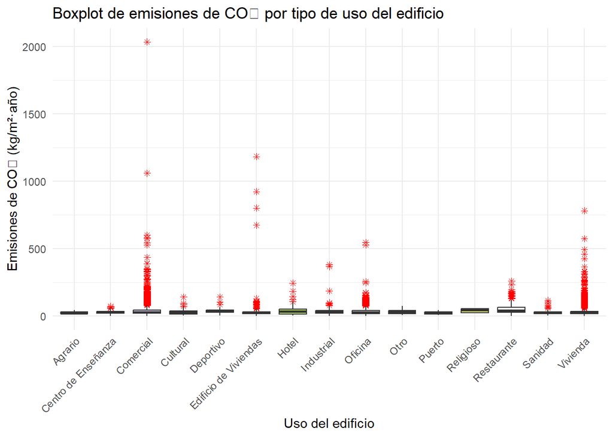

```r
# Generar boxplot original (con outliers)

generar_boxplot_por_uso(data)
```

```r
filas_a_eliminar <- data.frame(
  USO_EDIFICIO = rep("VIVIENDA INDIVIDUAL", 12),
  EMISIONES_CO2_VALOR = c(783, 783, 576, 494, 461, 365, 334, 332, 328, 315, 296, 288),
  SUPERFICIE_M2 = c(728.000, 728.000, 521.000, 439.000, 406.000, 310.000, 279.000, 277.000, 273.000, 260.000, 241.000, 233.000),
  ANYO_CONSTRUCCION = c(1973, 1955, 1970, 1931, 1997, 1960, 1966, 1981, 1960, 1966, 1955, 1890),
  CODIGO_POSTAL = c(46026, 46006, 46024, 46006, 46007, 46024, 46023, 46012, 46900, 46017, 46019, 46001),
  parcela_catastral = c(
    "6202901YJ2760A", "5714130YJ2751F", "9312408YJ2791C", "6016403YJ2761E", "4610805YJ2741B",
    "9505401YJ2790F", "8316420YJ2781E", "0800701YJ3600B", "7989803YJ1678N", "4697202YJ2649H",
    "5648405YJ2754H", "5728309YJ2752H"
  ),
  lat = c(
    39.45331, 39.46096, 39.46737, 39.46279, 39.45825,
    39.46697, 39.46845, 39.52726, 39.46618, 39.44596,
    39.49286, 39.47357
  ),
  lon = c(
    -0.3721880, -0.3771560, -0.3357290, -0.3740960, -0.3896420,
    -0.3324780, -0.3464060, -0.4334920, -0.3505950, -0.3906090,
    -0.3769920, -0.3768470
  )
)

library(dplyr)

data <- anti_join(data, filas_a_eliminar, by = c(
  "USO_EDIFICIO", "EMISIONES_CO2_VALOR", "SUPERFICIE_M2",
  "ANYO_CONSTRUCCION", "CODIGO_POSTAL", "parcela_catastral",
  "lat", "lon"
))

# Corrección de filas
# 1. Crear el data.frame con las correcciones
coord_corregidas <- data.frame(
  parcela_catastral = c("000720100YJ16C", "001430800YJ06F", "001431900YJ06F",
                        "0036613YJ2703N", "1449317YJ3514G", "1776551YJ2717N"),
  lat_nueva = c(39.401366901191494, 39.41586484113674, 39.41747731892181,
                39.482406786374035, 39.48233225977674, 39.51680882117547),
  lon_nueva = c(-0.5415714942790637, -0.5991076441776843, -0.5985237400117808,
                -0.4423017452644876, -0.4422910164289535, -0.4216401894407453)
)

# 2. Hacer el join y reemplazar solo las coordenadas que coincidan
data_parcelas<- data %>%
  left_join(coord_corregidas, by = "parcela_catastral") %>%
  mutate(
    lat = ifelse(!is.na(lat_nueva), lat_nueva, lat),
    lon = ifelse(!is.na(lon_nueva), lon_nueva, lon)
  ) %>%
  select(-lat_nueva, -lon_nueva)

#Se observa errores con algunas referecias así que se eliminan
# Crear el vector de referencias a eliminar
referencias_a_eliminar <- c(
  "46246A03300153", "5481413YJ2658A", "6462907YJ2766A", "46246A02700129", "46246A02500187",
  "46246A03001172", "4155617YJ2745E", "46246A03000417", "7173219YJ1677S", "46246A02600336",
  "5574209YJ2657S", "46246A03001226", "7728122YJ2772H", "5912335YJ2751B", "6212322YJ2761C",
  "46246A02600652", "46246A03001304", "6520819YJ2762B", "46246A03100108", "4723124YJ1742S",
  "5583104YJ1758S", "2428811YJ2722N", "46246A02600539", "6519422YJ2761H", "46246A02700106",
  "4045808YJ2644N", "9826603YJ2792F", "46246A03001029", "46246A00900243", "8485807YJ1688N",
  "5738220YJ2753H", "46246A02900017", "2431707YJ2723S", "4523104YJ1742S", "46246A03000069",
  "7932211YJ2773D", "7913208YJ1871S", "46246A03000108", "7365530YJ1676N", "5773116YJ1657S",
  "002040900YJ06F", "46246A04700031", "5913108YJ2751D", "5482503YJ1658S", "5944120YJ2754D",
  "46246A03200101", "46246A03200160", "5247418YJ2754G", "7624409YJ2772D", "9307111YJ2790E",
  "7612310YJ1871S", "46246A02600558", "46246A03001362", "46246A03001105", "5292113YJ1759S",
  "6943313YJ2764D", "6682110YJ1768S", "4338605YJ2743G", "6017411YJ2761E", "46246A02600472",
  "5571365YJ2657S", "46246A03200170", "46246A04800018", "9622315YJ2792D", "4655810YJ2745F",
  "7975108YJ1677N", "5384708YJ1758S", "5586718YJ1758N", "46246A04800152", "5172805YJ2657S",
  "46246A04900042", "46246A03000901", "2068514YJ2726N", "46246A03000794", "9940302YJ2794B",
  "9626418YJ2792F", "46246A04600140", "46246A03200074", "7612308YJ1871S", "46246A03001411",
  "8223722YJ2782C", "46246A03001317", "5583108YJ1758S", "8390608YJ1689S", "5582907YJ1758S",
  "46246A00100105", "5841220YJ2754B", "9937621YJ2793F", "2877916YJ2627N", "7520614YJ2772B",
  "46246A02600453", "46246A03001107", "46246A03200158", "46246A02900100", "2263112YJ2726S",
  "46246A00200424", "46246A05200099", "46246A02900107", "46246A02600470", "9415316YJ2791E",
  "3645213YJ2634N", "4220318YJ2742A"
)

# Filtrar las parcelas que NO están en la lista
data_parcelas <- data_parcelas %>%
  filter(!parcela_catastral %in% referencias_a_eliminar)
```

```r
library(e1071)
resumen_emisiones <- data %>%
  summarise(
    n              = sum(!is.na(EMISIONES_CO2_VALOR)),
    media          = mean(EMISIONES_CO2_VALOR, na.rm = TRUE),
    mediana        = median(EMISIONES_CO2_VALOR, na.rm = TRUE),
    desviacion     = sd(EMISIONES_CO2_VALOR, na.rm = TRUE),
    minimo         = min(EMISIONES_CO2_VALOR, na.rm = TRUE),
    Q1             = quantile(EMISIONES_CO2_VALOR, 0.25, na.rm = TRUE),
    Q3             = quantile(EMISIONES_CO2_VALOR, 0.75, na.rm = TRUE),
    maximo         = max(EMISIONES_CO2_VALOR, na.rm = TRUE),
    asimetria      = skewness(EMISIONES_CO2_VALOR, na.rm = TRUE),
    curtosis       = kurtosis(EMISIONES_CO2_VALOR, na.rm = TRUE)
  )

print(resumen_emisiones)
```

```
##        n   media mediana desviacion minimo Q1 Q3 maximo asimetria curtosis
## 1 150856 29.4045      27   17.94028      0 20 35   2035   19.1532 1411.879
```

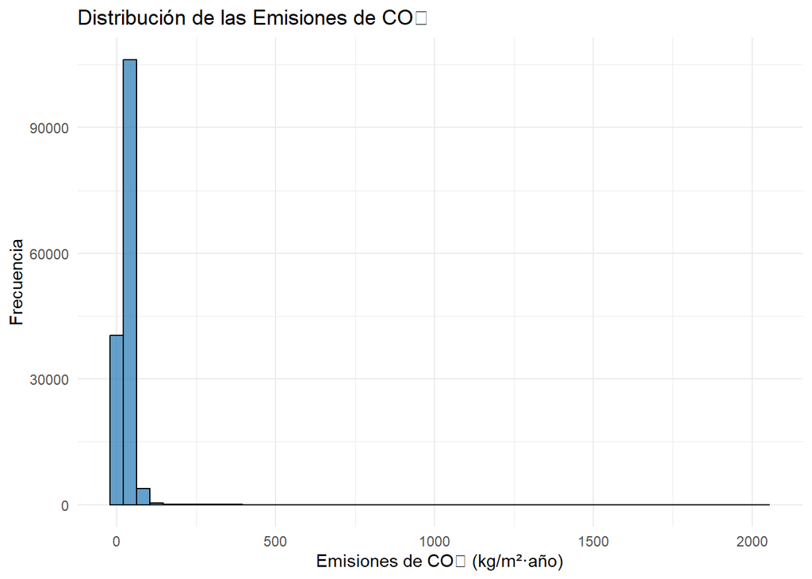

```r
library(ggplot2)

ggplot(data, aes(x = EMISIONES_CO2_VALOR)) +
  geom_histogram(bins = 50, fill = "#1f77b4", color = "black", alpha = 0.7) +
  labs(
    title = "Distribución de las Emisiones de CO₂",
    x = "Emisiones de CO₂ (kg/m²·año)",
    y = "Frecuencia"
  ) +
  theme_minimal()
```

La media y mediana se encuentran muy próximas, nos ofrece una dispersión moderada respecto a la media. Si hablamos de la asímetría nos ofrece la información que está muy sesgada a la deracha y tiene alta curtosis, lo que indica que hay una gran cantidad de valores extremos.

Se observa la fila que emite 2035 kg/m²·año,

```
##   ANYO_CONSTRUCCION uso_simplificado CODIGO_POSTAL EMISIONES_CO2_VALOR
## 1              1993        Comercial         46470                2035
##   SUPERFICIE_M2 parcela_catastral      lat       lon EMISIONES_CO2_LETRA
## 1          1540    3754704YJ2635S 39.49776 -0.399536                   G
##   MUNICIPIO_REFERENCIAS    USO_EDIFICIO
## 1             CATARROJA LOCAL COMERCIAL
```

Se elimina dicho inmueble, se trata de un bar y parece muchas emisiones aunque sea viejo y con mala eficiencia energética.

```
##        n   media mediana desviacion minimo Q1 Q3 maximo asimetria curtosis
## 1 150855 29.3912      27   17.18114      0 20 35   1185  11.26411 448.2052
```

```
##   ANYO_CONSTRUCCION      uso_simplificado CODIGO_POSTAL EMISIONES_CO2_VALOR
## 1              1800 Edificio de Viviendas         46003                1185
##   SUPERFICIE_M2 parcela_catastral     lat       lon EMISIONES_CO2_LETRA
## 1          1240    5632313YJ2753D 39.4778 -0.377418                   G
##   MUNICIPIO_REFERENCIAS                            USO_EDIFICIO
## 1              VALENCIA EDIFICIO DE VIVIENDAS (BLOQUE COMPLETO)
```

```
##        n   media mediana desviacion minimo Q1 Q3 maximo asimetria curtosis
## 1 150855 29.3912      27   17.18114      0 20 35   1185  11.26411 448.2052
```

Para hacer clustering que es el objetivo principal de este objetivo no se necesita tener datos normalizados. decidimos no eliminar más datos.

## Estudio Preliminar Códigos Postales

Queremos ver la cantidad de certificados que hay por código postal y la letra de emisiones de CO2, para ver si hay algún patrón.

```
## # A tibble: 54 × 10
##    CODIGO_POSTAL MUNICIPIO_REFERENCIAS     A     B     C     D     E     F     G
##            <int> <chr>                 <int> <int> <int> <int> <int> <int> <int>
##  1         46001 VALENCIA                 11    45   218   453  1472   177   213
##  2         46002 VALENCIA                  7    48   194   339   700   106    94
##  3         46003 VALENCIA                 14    44   221   483  1486   156   196
##  4         46004 VALENCIA                 10    89   240   432   942    96    91
##  5         46005 VALENCIA                 12    51   251   608  1905   198   161
##  6         46006 VALENCIA                 16   116   504  1294  5050   478   513
##  7         46007 VALENCIA                 25   100   464  1231  4395   446   431
##  8         46008 VALENCIA                 23    86   367   910  3061   272   279
##  9         46009 VALENCIA                 13    62   391   926  4273   398   398
## 10         46010 VALENCIA                 11    71   276   693  2247   190   175
## # ℹ 44 more rows
## # ℹ 1 more variable: Suma_Total <dbl>
```

```r
# Agrupar por código postal y letra, y calcular la media
tabla_medias <- data %>%
  filter(!is.na(EMISIONES_CO2_LETRA) & EMISIONES_CO2_LETRA != "") %>%
  group_by(CODIGO_POSTAL, EMISIONES_CO2_LETRA) %>%
  summarise(Media_Emisiones_CO2 = mean(EMISIONES_CO2_VALOR, na.rm = TRUE), .groups = "drop")

# Pivotar y renombrar
tabla_medias_pivotada <- tabla_medias %>%
  pivot_wider(
    names_from = EMISIONES_CO2_LETRA,
    values_from = Media_Emisiones_CO2,
    values_fill = list(Media_Emisiones_CO2 = NA)
  )

# Mostrar tabla
print(tabla_medias_pivotada)
```

```
## # A tibble: 49 × 8
##    CODIGO_POSTAL     A     B     C     D     E     F     G
##            <int> <dbl> <dbl> <dbl> <dbl> <dbl> <dbl> <dbl>
##  1         46001 18.3   13.4  20.8  21.3  28.8  46.2  62.8
##  2         46002  8.14  21.8  24.6  25.2  29.2  48.4  63.5
##  3         46003 15.8   18.3  21.6  21.0  28.2  45.1  68.6
##  4         46004 14.1   15.4  20.3  21.7  27.8  46.2  63.9
##  5         46005  9.67  17.8  19.1  19.6  27.8  42.6  66.7
##  6         46006 17.8   17.9  19.2  19.9  27.7  42.5  65.0
##  7         46007 13.5   16.0  19.0  19.2  27.5  44.5  62.3
##  8         46008 15.7   19.7  19.9  19.8  27.5  43.9  60.1
##  9         46009 10.2   21.0  21.6  19.5  28.1  44.0  59.4
## 10         46010  7.91  14.3  20.8  18.5  27.4  42.1  59.3
## # ℹ 39 more rows
```

# Gráfico de barras apiladas de las emisiones de CO2

```r
library(dplyr)
library(tidyr)
library(ggplot2)

# Definir los colores por categoría energética
colores_categorias <- c(
  "A" = "#4CAF50",     # Verde oscuro
  "B" = "#8BC34A",     # Verde claro
  "C" = "#CDDC39",     # Amarillo verdoso
  "D" = "#FFEB3B",     # Amarillo
  "E" = "#FFC107",     # Naranja claro
  "F" = "#FF5722",     # Naranja oscuro
  "G" = "#F44336"      # Rojo
)

# 1. Calcular suma total por fila (excluyendo columnas no numéricas)
tabla_frecuencias_ordenada <- tabla_frecuencias_pivotada %>%
  mutate(Suma_Total = rowSums(across(where(is.numeric) & !c(CODIGO_POSTAL)), na.rm = TRUE)) %>%
  group_by(CODIGO_POSTAL) %>%
  arrange(CODIGO_POSTAL, desc(Suma_Total)) %>%
  ungroup()

# 2. Convertir a formato largo para ggplot (excluyendo Suma_Total)
tabla_frecuencias_pivotada_long <- tabla_frecuencias_ordenada %>%
  select(-Suma_Total) %>%
  pivot_longer(
    cols = -c(CODIGO_POSTAL, MUNICIPIO_REFERENCIAS),
    names_to = "Categoria",
    values_to = "Frecuencia"
  )

# 3. Crear gráfico por municipio
municipios <- unique(tabla_frecuencias_pivotada_long$MUNICIPIO_REFERENCIAS)
graficos <- list()

for (mun in municipios) {
  datos_municipio <- tabla_frecuencias_pivotada_long %>%
    filter(MUNICIPIO_REFERENCIAS == mun) %>%
    mutate(CODIGO_POSTAL = factor(CODIGO_POSTAL, levels = unique(CODIGO_POSTAL)))

  grafico <- ggplot(datos_municipio, aes(x = CODIGO_POSTAL, y = Frecuencia, fill = Categoria)) +
    geom_bar(stat = "identity") +
    scale_fill_manual(values = colores_categorias) +
    labs(
      x = "Código Postal",
      y = "Frecuencia",
      title = paste("Distribución de letras energéticas en", mun)
    ) +
    theme_minimal() +
    theme(axis.text.x = element_text(angle = 90, hjust = 1))

  nombre_variable <- paste0(gsub(" ", "_", tolower(mun)), "_grafico_letras")
  assign(nombre_variable, grafico, envir = .GlobalEnv)
  graficos[[nombre_variable]] <- grafico
}
```

```r
for (grafico in graficos) {
  print(grafico)
}
```

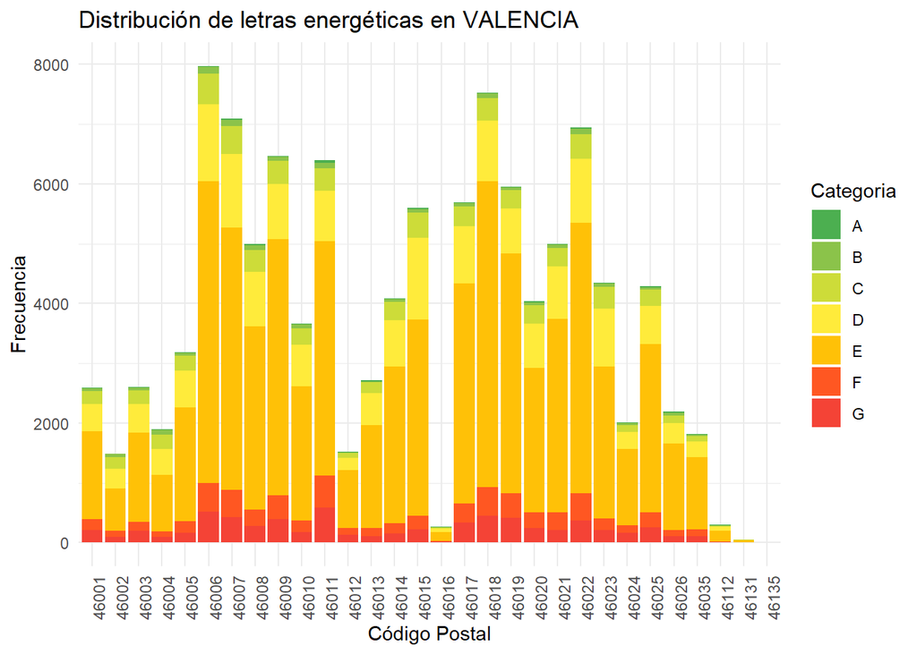

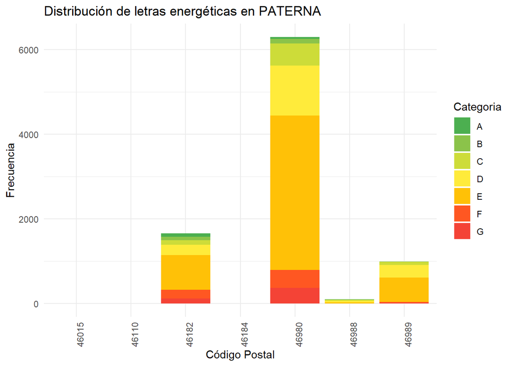

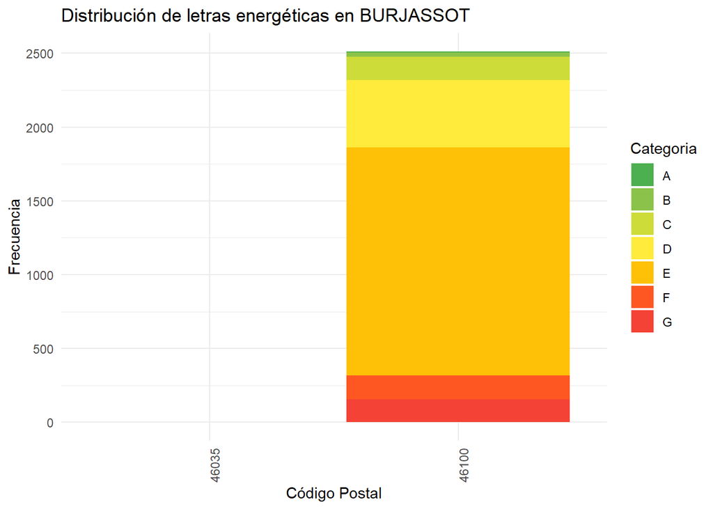

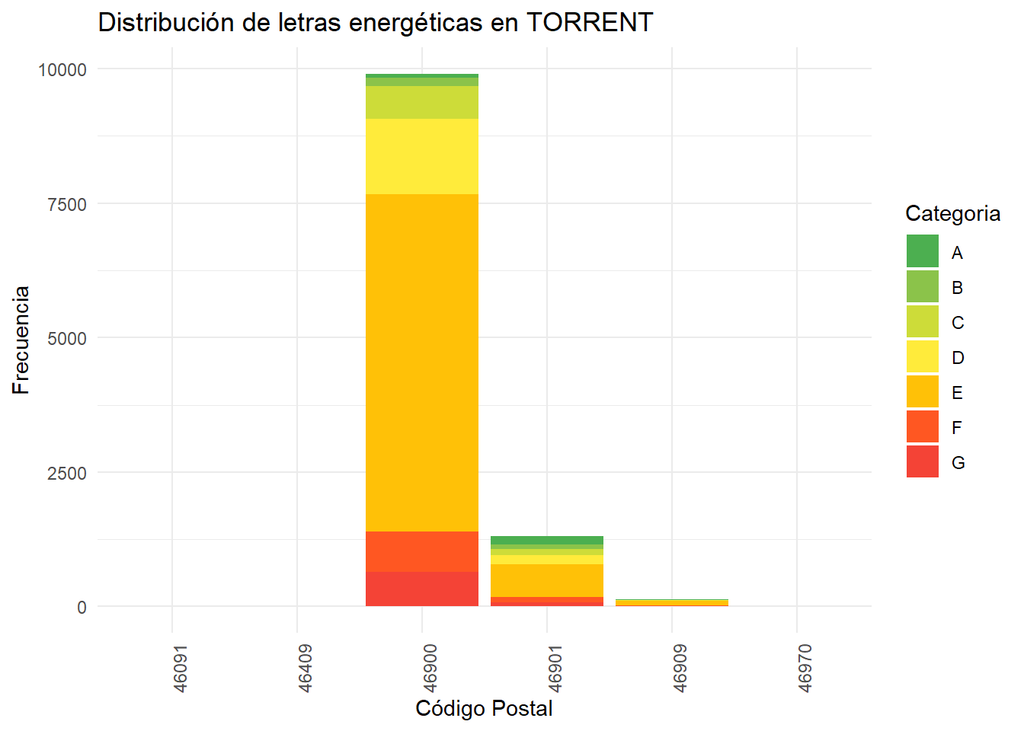

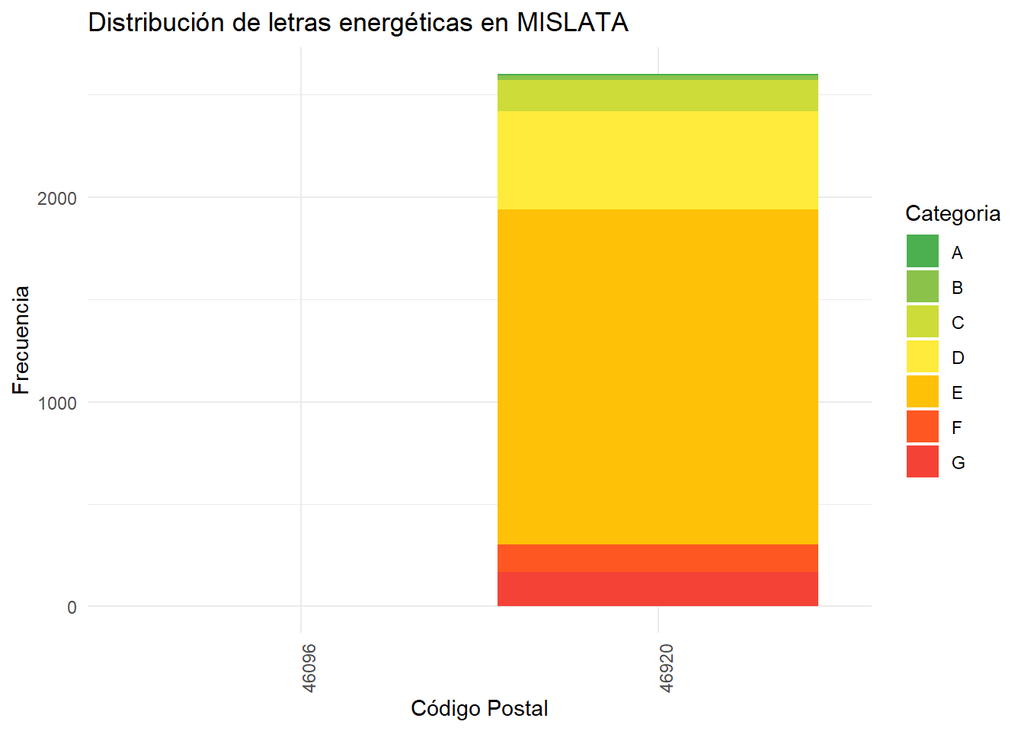

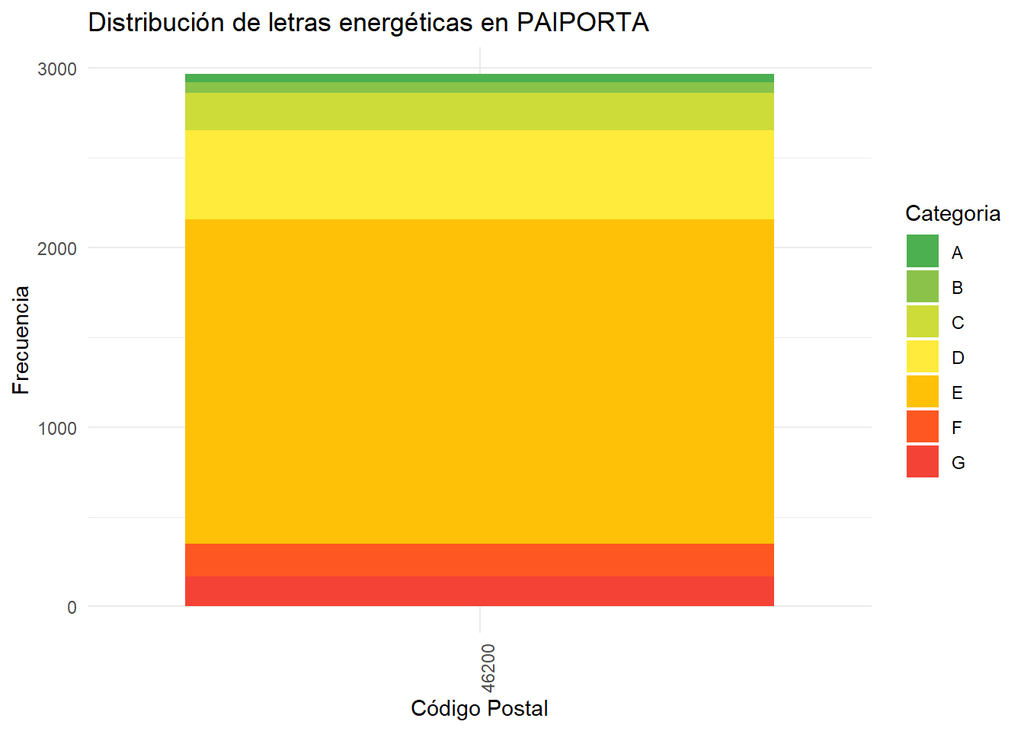

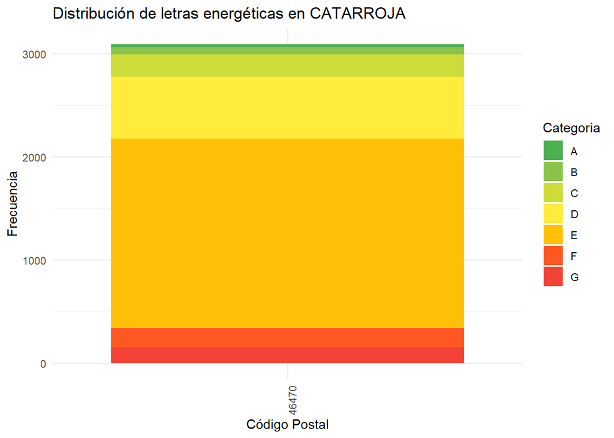

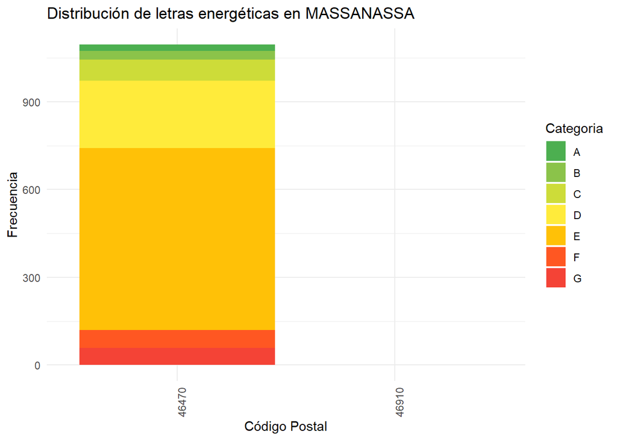

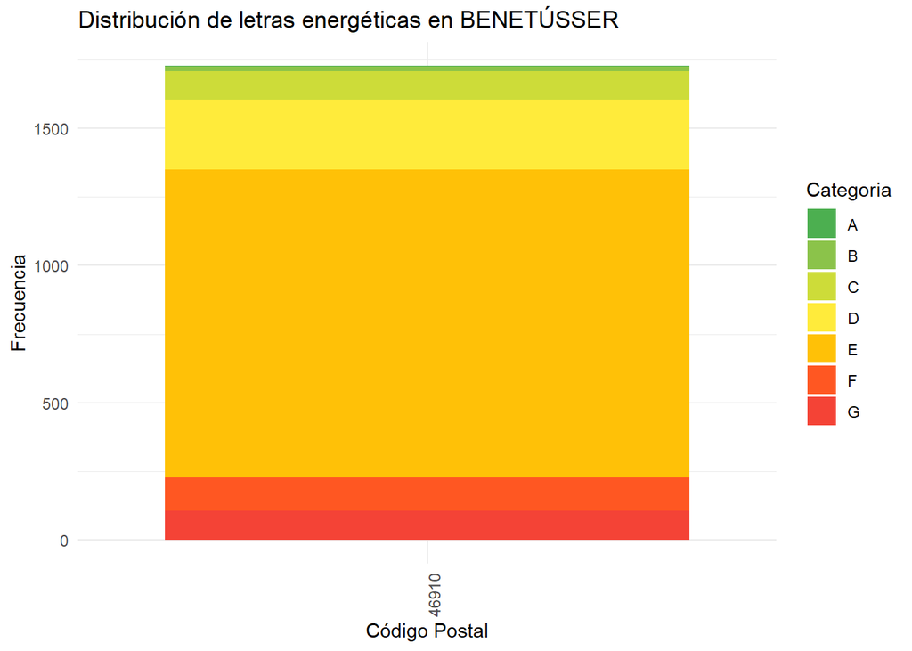

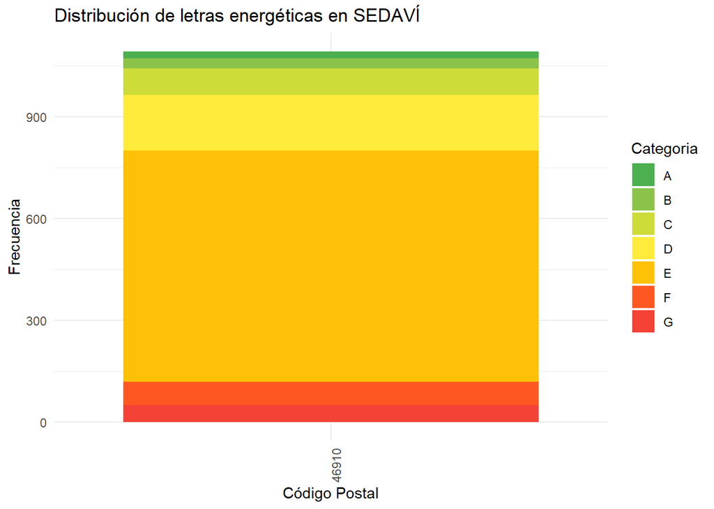

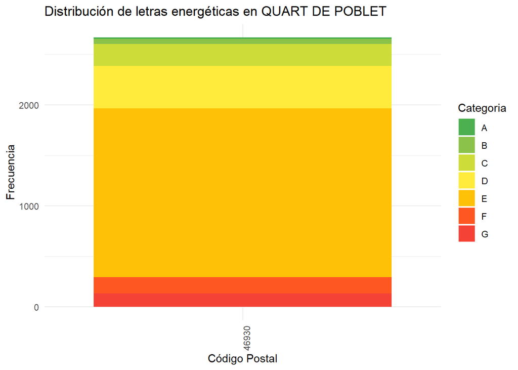

Se puede observar que en todos los barrios siguen una proporción parecida en las calificaciones de las emisiones, siendo Valencia la ciudad con más certificados energéticos realizados. Aunque estén incentivando la mejora de eficiencia energética y la reducción de la huella de carbono, se puede ver que las viviendas mejores califcadas aún siguen siendo pocas.

# Tabla de medias de emisiones de CO2

```
## # A tibble: 49 × 3
##    CODIGO_POSTAL Media_Emisiones_CO2 EMISIONES_CO2_LETRA
##            <int>               <dbl> <chr>
##  1         46001                30.5 E
##  2         46002                30.9 E
##  3         46003                30.1 E
##  4         46004                27.4 D
##  5         46005                28.2 D
##  6         46006                29.0 E
##  7         46007                28.5 D
##  8         46008                28.1 D
##  9         46009                29.3 E
## 10         46010                27.2 D
## # ℹ 39 more rows
```

# Tabla frecuencia uso_simplificado

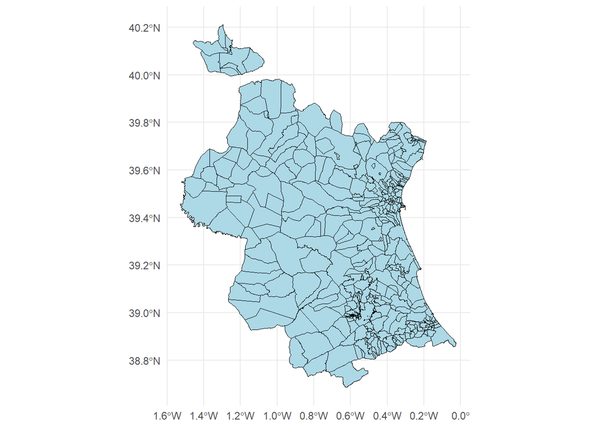

```
## [1] "ID_CP"      "COD_POSTAL" "ALTA_DB"    "CODIGO_INE" "geometry"
```

```
##  [1] "CODIGO_POSTAL"         "Vivienda"              "Comercial"
##  [4] "Edificio de Viviendas" "Oficina"               "Restaurante"
##  [7] "Hotel"                 "Centro de Enseñanza"   "Otro"
## [10] "Cultural"              "Religioso"             "Industrial"
## [13] "Sanidad"               "Deportivo"             "Puerto"
## [16] "Agrario"               "Total_Usos"            "Uso_Dominante"
```

```
## [1] "CODIGO_POSTAL" "E"             "D"             "G"
## [5] "F"
```

```
## [1] "ID_CP"         "CODIGO_POSTAL" "ALTA_DB"       "CODIGO_INE"
## [5] "geometry"
```

```
## [1] "CODIGO_POSTAL"       "Media_Emisiones_CO2" "EMISIONES_CO2_LETRA"
```

```
##  [1] "CODIGO_POSTAL"         "MUNICIPIO_REFERENCIAS" "A"
##  [4] "B"                     "C"                     "D"
##  [7] "E"                     "F"                     "G"
## [10] "Suma_Total"
```

```
## [1] "CODIGO_POSTAL" "E"             "D"             "G"
## [5] "F"
```

# Ejemplo de popup

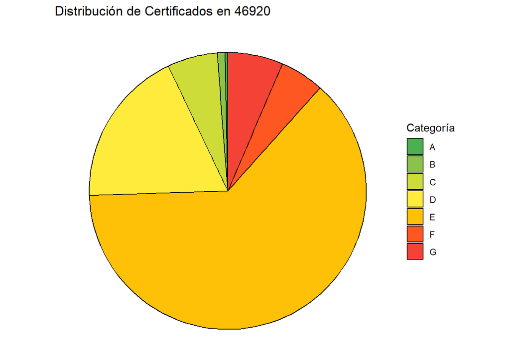

```
## # A tibble: 7 × 4
##   Categoria Cantidad Media_CO2 Porcentaje
##   <chr>        <int>     <dbl>      <dbl>
## 1 A                8      NA        0.307
## 2 B               24      NA        0.922
## 3 C              152      NA        5.84
## 4 D              480      NA       18.4
## 5 E             1636      29.0     62.9
## 6 F              134      NA        5.15
## 7 G              168      NA        6.46
```

[figure not shown]

```
## # A tibble: 16 × 3
##    Uso                   Cantidad Porcentaje
##    <chr>                    <dbl>      <dbl>
##  1 Total_Usos                2589    50
##  2 Vivienda                  2046    39.5
##  3 Comercial                  310     5.99
##  4 Edificio de Viviendas      124     2.39
##  5 Oficina                     74     1.43
##  6 Restaurante                 20     0.386
##  7 Hotel                        5     0.0966
##  8 Centro de Enseñanza          4     0.0772
##  9 Otro                         3     0.0579
## 10 Cultural                     2     0.0386
## 11 Religioso                    1     0.0193
## 12 Industrial                   0     0
## 13 Sanidad                      0     0
## 14 Deportivo                    0     0
## 15 Puerto                       0     0
## 16 Agrario                      0     0
```

```
##  [1] "ID_CP"                 "CODIGO_POSTAL"         "ALTA_DB"
##  [4] "CODIGO_INE"            "Media_Emisiones_CO2"   "EMISIONES_CO2_LETRA"
##  [7] "MUNICIPIO_REFERENCIAS" "A"                     "B"
## [10] "C"                     "D.x"                   "E.x"
## [13] "F.x"                   "G.x"                   "Suma_Total"
## [16] "E.y"                   "D.y"                   "G.y"
## [19] "F.y"                   "Vivienda"              "Comercial"
## [22] "Edificio de Viviendas" "Oficina"               "Restaurante"
## [25] "Hotel"                 "Centro de Enseñanza"   "Otro"
## [28] "Cultural"              "Religioso"             "Industrial"
## [31] "Sanidad"               "Deportivo"             "Puerto"
## [34] "Agrario"               "Total_Usos"            "Uso_Dominante"
## [37] "geometry"
```

# Mapa intecractivo de emisiones de CO2

### 🏚️ Zonas residenciales con mayores emisiones

- En el **Cabanyal (46011)** y áreas portuarias, se superan los **30 kg/m²·año** de media.  
  👉 Esto es coherente con la presencia de **viviendas antiguas y sin rehabilitación energética**.
- Otras zonas como el **Carmen** o **partes de Russafa** presentan también valores elevados, probablemente debido a **bloques de viviendas envejecidos**.

### 🏭 Sectores con uso industrial o terciario

- En áreas como **Paterna (46980, 46988)** las emisiones son elevadas y **coherentes con su uso dominante**:
  - **Oficinas**
  - **Naves industriales**
  - **Grandes superficies**

Estas tipologías suelen tener **consumos energéticos mayores**, justificando los valores observados.

### ✅ Conclusiones del análisis espacial

- Existen **diferencias claras** entre zonas residenciales, comerciales e industriales.
- Los **barrios más antiguos presentan peores indicadores** de eficiencia energética.
- El análisis permite **identificar prioridades de intervención** y **verificar posibles errores** en la base de datos.

### Agrupar edificios para identificar los comportamientos en la ciudad de Valencia

Realizar un **clustering jerárquico** que agrupe edificios de Valencia en función de:

- **Emisiones de CO₂ por m²·año**
- **Antigüedad del edificio**
- **Superficie construida**
- **Uso principal del edificio** (transformado a dummies)

Buscamos **detectar patrones de comportamiento energético** entre edificios con características similares, lo que puede ayudar a:

- Identificar zonas críticas.
- Orientar políticas de rehabilitación energética.
- Relacionar los clusters con otros factores (tráfico, contaminación, etc.).

# Muestra

Debido a la extensión de los datos, se ha decidido hacer una muestra estratificada por uso, y consideramos que es la mejor forma de reducir el tamaño del dataset sin perder representatividad de los diferentes tipos de edificios, para un 99% de confianza y en error +-1% necesitaríamos una muestra de 14988 registros

# Verificar la muestra

Se pensó en hacer una prueba de t de student, pero no tenemos datos que sigan la distribución de normalidad, por lo que se ha decidido hacer una prueba de Wilcoxon, que es más robusta a la no normalidad de los datos.

Hipótesis:

H₀ (nula): la media de la muestra es igual a la media de la población.

H₁ (alternativa): la media de la muestra no es igual a la media de la población.

```
## # A tibble: 3 × 3
##   variable            p_value reject_null
##   <chr>                 <dbl> <lgl>
## 1 EMISIONES_CO2_VALOR   0.264 FALSE
## 2 SUPERFICIE_M2         0.732 FALSE
## 3 antiguedad           NA     NA
```

No rechazamos la hipótesis nula, por lo que podemos concluir que la media de muestra es representativa de la población y podemos seguir con nuestro objetivo.

# Crear variable

Calcular antigüedad. La edad de un edificio afecta directamente a su comportamiento energético. Los edificios más antiguos suelen tener peor aislamiento, instalaciones ineficientes y peores materiales constructivos. Usamos 2025 como referencia fija para comparar todos los casos.

# Selección de variables

Incluimos únicamente las variables que aportan información útil al análisis, y eliminamos aquellas observaciones incompletas que podrían distorsionar los resultados (clustering no tolera bien los NA).

EMISIONES_CO2_VALOR: variable clave a estudiar.

Antigüedad: impacto estructural.

SUPERFICIE_M2: tamaño influye en demanda energética.

uso_simplificado: es un determinante del comportamiento del edificio.

# Codificar la variable categórica uso_simplificado con variables dummy

Los algoritmos de clustering no trabajan directamente con variables categóricas. Por eso convertimos cada uso posible en una variable binaria 0/1 (si es de ese tipo o no). Esto permite representar diferentes tipos de uso (vivienda, oficina, comercial…) sin orden artificial.

# Escalado y centrado de variables

Los algoritmos de clustering son sensibles a la escala de las variables. Si una variable (como SUPERFICIE_M2) tiene un rango muy alto, dominará la distancia total, anulando el efecto de las demás.

# Elegir Distancia

| Distancia | Tipo de datos | ¿Adecuada para tu caso? | Comentario breve |
| --- | --- | --- | --- |
| **Euclídea** | Solo numéricas | ❌ Parcialmente | No trata bien las dummies como categóricas |
| **Manhattan** | Numéricas | ❌ Parcialmente | Más robusta, pero mismo problema |
| **Gower** | **Mixtos** (num + categóricas) | ✅ **Sí, la mejor opción** | Trata bien variables numéricas y categóricas |
| Coseno | Numéricas, escala similar | ❌ | Más para texto o vectores dirección |
| Correlación | Numéricas | ❌ | Para perfiles de comportamiento, no valores brutos |

# Cálculo de clusters ideal

Se ha probado a hacer directamente pero tras 15 min de ejecución se ha decidido hacer un PCA para reducir la cantidad de variables y así acelerar el proceso, como ya no tendremos un dataset mixto utilizaremos la distancia euclidea.

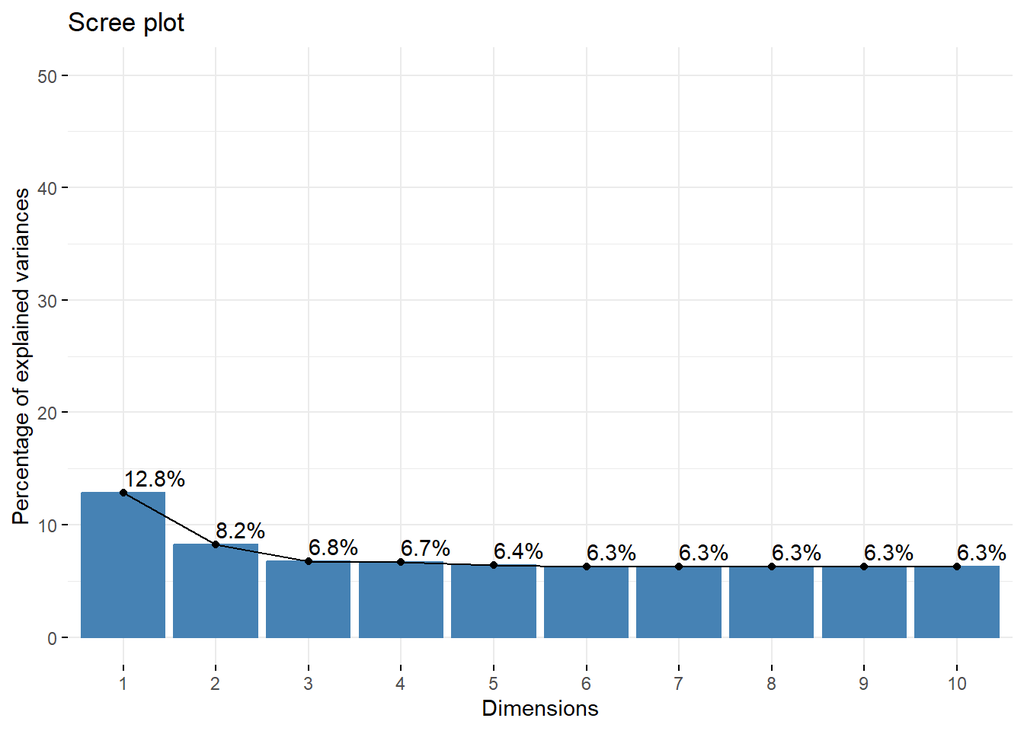

```
## Too few points to calculate an ellipse
## Too few points to calculate an ellipse
```

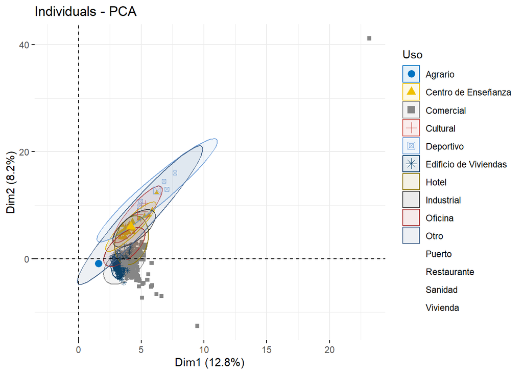

Se decide usar para el clustering las 10 componentes principales, ya que explican el 72,4% de la varianza de los datos, no tienen correlación entre ellas . En este caso las variables ahora son cuantitavias así que son todas cuantitativas y se puede usar la distancia euclidea. La distancia euclidea nos calcula la distancia entre dos puntos de forma geométrica. Se ha usado el método de Ward por que se desea minimizar la varianza dentro de cada cluster, lo que es útil para crear grupos homogéneos. El método Ward.D2 (que es la versión moderna) agrupa los puntos minimizando el aumento de varianza total al fusionar dos clusters: por lo que agrupa puntos cercanos y tiene en cuenta la forma y dispersión de los grupos.

# Creación Clusters

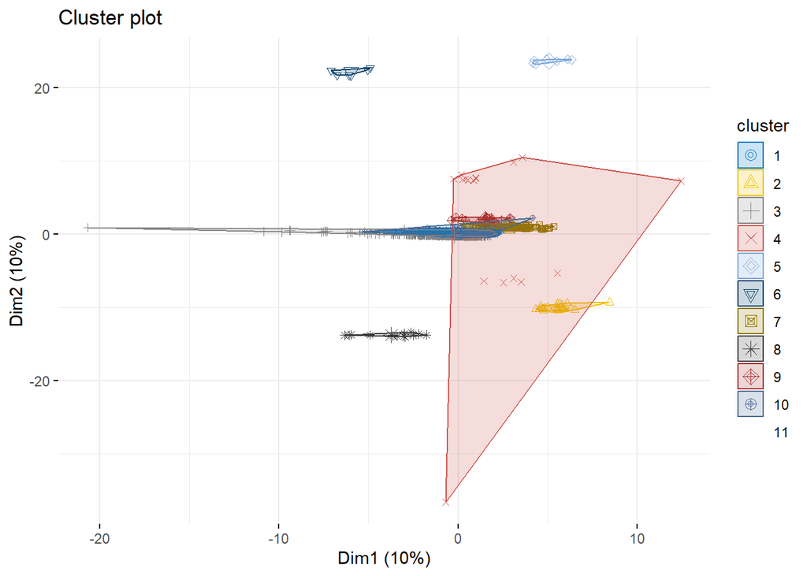

Obsevamos las estadísticas de los 11 clusters

```
## # A tibble: 11 × 9
##    cluster     n media_CO2 mediana_CO2 sd_CO2 media_sup mediana_sup media_antig
##    <fct>   <int>     <dbl>       <dbl>  <dbl>     <dbl>       <dbl>       <dbl>
##  1 1       13076      28.5          27  12.7      1111.        990         51.8
##  2 2          31      25.6          27   9.91     4457.       3549         47.0
##  3 3        1316      37.4          30  31.4      1557.       1150         54.3
##  4 4          18      29.3          28  14.6     13126        2990.        50.8
##  5 5           7      31.4          36  12.4      5637.       5910         37
##  6 6           5      46.2          38  23.2      8815.      10593         32.4
##  7 7         231      26.6          27  11.5      1468.       1160         69.7
##  8 8          13      42.2          28  34.9      3700.       2860         42.3
##  9 9          21      34.7          33  16.7      4643.       5330         43.9
## 10 10        231      34.8          28  23.4      2533.       1530         42.6
## 11 11         39      48.2          41  29.5      2057.       1333         49.2
## # ℹ 1 more variable: mediana_antig <dbl>
```

```
## # A tibble: 11 × 15
##    cluster Agrario Vivienda `Centro de Enseñanza` Comercial  Otro Puerto Sanidad
##    <fct>     <int>    <int>                 <int>     <int> <int>  <int>   <int>
##  1 1             1    13075                     0         0     0      0       0
##  2 2             0        0                    31         0     0      0       0
##  3 3             0        4                     0      1312     0      0       0
##  4 4             0        0                     0         1     5      1      11
##  5 5             0        0                     0         0     0      0       0
##  6 6             0        0                     0         0     0      0       0
##  7 7             0        0                     0         0     0      0       0
##  8 8             0        0                     0         0     0      0       0
##  9 9             0        0                     0         0     0      0       0
## 10 10            0        0                     0         0     0      0       0
## 11 11            0        0                     0         0     0      0       0
## # ℹ 7 more variables: Cultural <int>, Deportivo <int>,
## #   `Edificio de Viviendas` <int>, Hotel <int>, Industrial <int>,
## #   Oficina <int>, Restaurante <int>
```

Queremos observar el número de edificios por cluster.

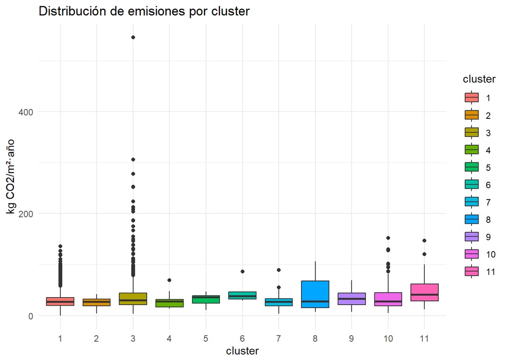

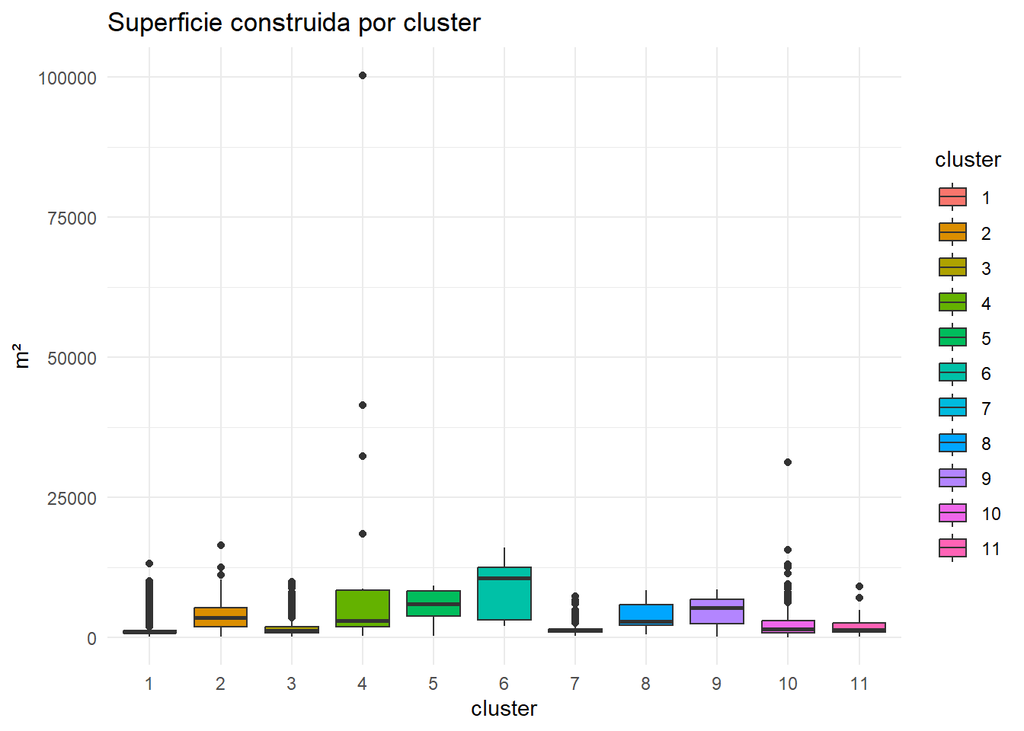

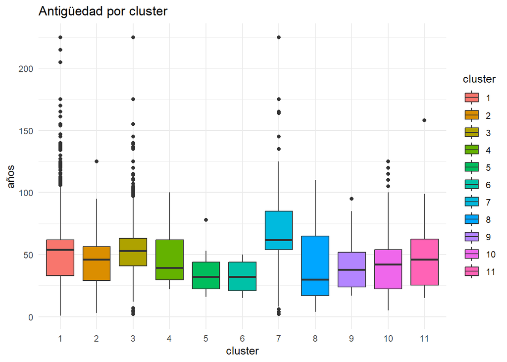

GRUPO 1: representa el comportamiento medio de los edificios en Valencia. Predominan las viviendas con valores intermedios de antigüedad y emisiones. Su comportamiento energético se puede considerar como “estándar” y puede servir como referencia para comparación con otros grupos.

GRUPO 2: Edificios con mejor comportamiento energético. Se basa en centro educativos

GRUPO 3 Agrupa edificios comerciales con necesidades energéticas elevadas. La superficie es superior a la del grupo 1 y las emisiones significativamente más altas, lo que apunta a un menor rendimiento energético o mayores necesidades de climatización.

grupo 4: Son edificios grandes y diversos, mayoritariamente públicos, cuya eficiencia varía. Su superficie y antigüedad sugieren instalaciones históricas o infraestructuras comunitarias.

GRUPO 5,6 Y 8: Estos grupos agrupan edificios con altas emisiones de CO₂, probablemente debido a su uso (gimnasios, hoteles, edificios mal acondicionados), alta superficie y/o antigüedad, el 6 y 8 tienen emisiones bastante altas.

GRUPO 7: Este grupo contiene viviendas más viejas que el grupo 1 pero contaminan menos, aunque no hay mucha diferencia

GRUPO 9 : son las industrias y en general emisioens algo más alta pero no son muy excesivo

GRUPO 10: Este grupo contiene edificios de oficinas Y sorprendentemente tienen la misma huella de carbono que las industrias.

GRUPO 11: Los restaurantes son de los que más CO2 emiten , lógicamente por el gran horario de servicio que disponen, las cocinas y el tema de climatiazción.

## Otro modelo de clustering

Se va a realizar el clustering tan solo con las emisiones de co2, superfice y antigüedad debido a que el clustering al incluir uso salen directamente los grupos asociados al uso. Después se intentará ver si podemos asociarlo a cierto grupo o hay dispersión. Se utilizará la distancia euclídea por ser variables numéricas y consideramos que los anómalos no tendran un gran peso.

# Visualización

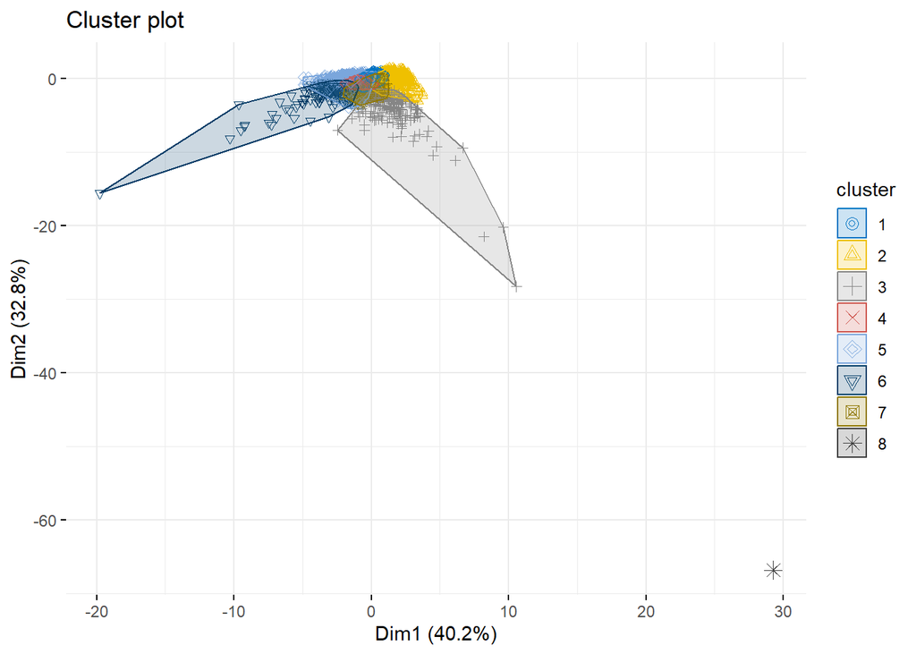

# Interpretación

```
## # A tibble: 8 × 15
##   cluster Agrario `Centro de Enseñanza` Comercial `Edificio de Viviendas` Hotel
##   <fct>     <int>                 <int>     <int>                   <int> <int>
## 1 1             1                     7       488                     128     2
## 2 2             0                    10       176                      21     1
## 3 3             0                    11        61                       6     4
## 4 4             0                     1       196                      14     0
## 5 5             0                     2       122                      59     0
## 6 6             0                     0       112                       2     3
## 7 7             0                     0       157                       1     3
## 8 8             0                     0         1                       0     0
## # ℹ 9 more variables: Industrial <int>, Oficina <int>, Otro <int>,
## #   Restaurante <int>, Sanidad <int>, Vivienda <int>, Deportivo <int>,
## #   Cultural <int>, Puerto <int>
```

```
## # A tibble: 8 × 9
##   cluster     n media_CO2 mediana_CO2 sd_CO2 media_sup mediana_sup media_antig
##   <fct>   <int>     <dbl>       <dbl>  <dbl>     <dbl>       <dbl>       <dbl>
## 1 1        6608      24.5          25   7.02     1048.         980        55.8
## 2 2        2897      18.0          18   5.98     1429.        1240        24.4
## 3 3         211      36.3          33  18.5      6942.        5970        48.6
## 4 4        2376      42.2          41   6.42      869.         790        59.7
## 5 5        1266      29.6          29  11.2      1150.         975       104.
## 6 6         419      81.7          71  38.6       886.         760        65.5
## 7 7        1210      39.6          36  11.8      1376.        1220        25.7
## 8 8           1      28            28  NA      100306       100306        24
## # ℹ 1 more variable: mediana_antig <dbl>
```

Se observa que el comportamiento del cluster 1 sigue el patrón normal de las emisiones de CO2 de zonas de la ciudad donde no hay un exceso de emisiones, lo que sería el comportamiento habitual del conjunto de la ciudad está formado por la mayoría de edificios de viviendas, oficinas, y sobre todo viviendas.

El grupo 2 tiene un comportamiento similar al grupo 1 pero con una media de emisiones de CO2 más baja, lo que podría indicar que son edificios más nuevos o con mejores características energéticas, destacan los colegios, que serán de creación reciente; y es el segundo con más viviendas lo que podría significar que son de nueva contrucción y por eso en el grupo de más bajas emisiones, si vemos la antigüedad es la más baja de todos los grupos, confirma que son los más novedosos y con grandes mejoras de eficiencia energética que el resto.

El grupo 3 tiene un comportamiento similar al grupo 1 pero con una media de emisiones de CO2 más alta, lo que podría indicar que son edificios más antiguos o con peores características energéticas, destaca la presencia de industrias, la cantidad de colegios se podría deber debido a su alta necesidad energética por ser espacio muy grandes y antigüamente no se invirtía tanto en eso, algo parecido ocurre con los gimnasios o centros deportivos son lugares en los que las personas están haciendo un esfuerzo físico y se tiene que climatizar las zonas y con mayor intensidad en especial en verano, es por eso que es lógico que este grupo tenga una media de superficie bastante alta y también destacan los hoteles que tienen un gasto energético superior a la media de edificios.

El grupo 4 destacan las viviendas viejas por ello mayor las emisiones de CO2.

El grupo 5 diría que son edificios y viviendas muy antiguos y a pesar de no tener buen aislamiento no cuentan con instalaciones de climatización y no emiten dicho gas y hay que añadir que hay un edificio del puerto, esto nos ayuda a entender que no emiten tanto CO2, cuando se limpiaron los datos se observó que la mayoría de lugares del puerto que estaban certificados eran naves de almacenamiento y no tenían apenas emisiones.

El grupo 6 tiene las peores emisiones de CO2, es un conjunto de todo, diría que son los peores en cuanto emisiones de co2 de cada uso de edificio.

El grupo 7 son hoteles, viviendas recientes pero diría que de peor calidad constructiva que las del grupo 2, y también hay oficinas y hoteles de las mismas características.

Finalmente el grupo 8 solo cuenta con un individuo y difiere del resto por su gran superficie, se trata de algo comercial, por la superficie diria un centro comercial.

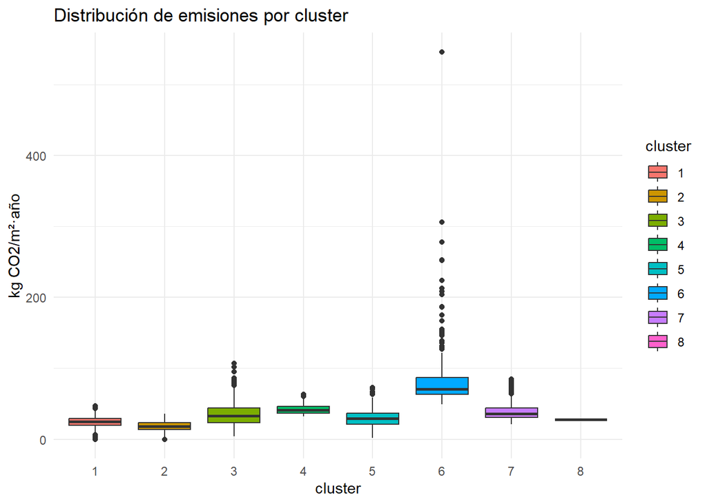

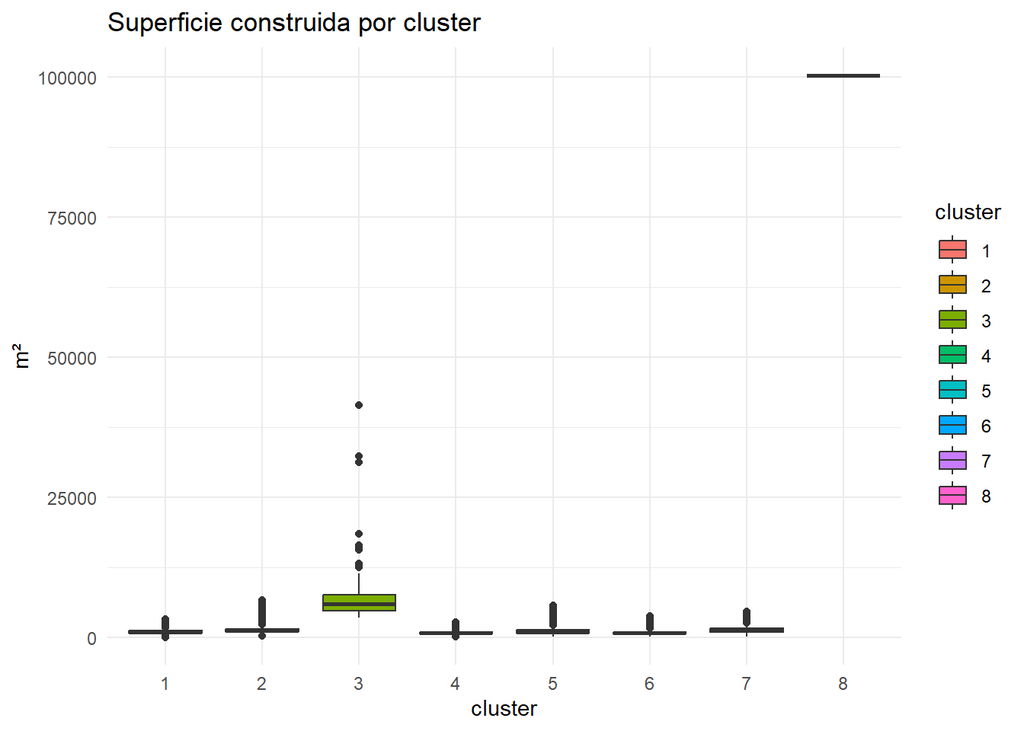

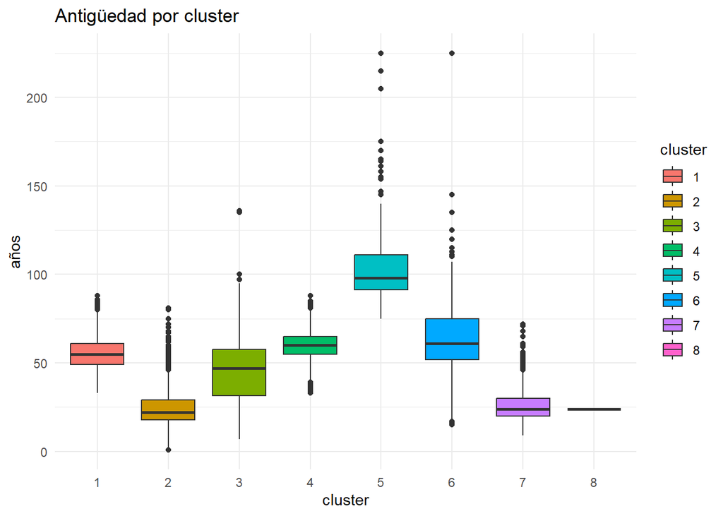

✅ Conclusiones generales sobre el comportamiento energético de los edificios de Valencia Predominio del comportamiento estándar y eficiente en la mayoría de los edificios

El grupo 1, mayoritario, representa el patrón habitual de emisiones de CO₂ en Valencia. Se compone sobre todo de viviendas y oficinas con emisiones moderadas, lo que refleja el comportamiento energético típico de la ciudad.

El grupo 2 destaca por tener las emisiones más bajas, asociadas a edificios más recientes, especialmente colegios y viviendas de nueva construcción, con mejor eficiencia energética y menor antigüedad.

Presencia de grupos con mayor impacto energético

El grupo 3 presenta emisiones más elevadas, con una composición marcada por industrias, centros deportivos, colegios antiguos y hoteles. Este grupo concentra usos con mayor demanda energética y construcciones más antiguas y menos eficientes.

El grupo 4 y grupo 6 incluyen viviendas envejecidas y un conjunto heterogéneo de edificios con las peores cifras de CO₂, respectivamente. Esto apunta a la existencia de zonas vulnerables energéticamente que podrían ser prioritarias en políticas de rehabilitación.

Casos especiales con patrones propios

El grupo 5 edificios muy antiguos pero con bajas emisiones, posiblemente por ausencia de climatización o funciones de almacenamiento sin consumo energético relevante (ej. naves en el puerto) y otros que han sido reformados.

El grupo 7 se compone de viviendas y hoteles relativamente recientes pero con peor comportamiento energético, posiblemente por materiales de baja calidad o mala eficiencia constructiva.

El grupo 8 representa un outlier, probablemente un centro comercial de gran superficie, cuyas características lo diferencian completamente del resto.

### Analizar la inflencia

Se agrupan los datos por parcelas catastrales y reorganizamos las categorías de uso para que sean más comprensibles, se suma superficies y se calcula la media de emisiones de co2. Se busca estudiar la posible inlfuencia del CO2 a los contaminantes.

```
## # A tibble: 10 × 8
##    parcela_catastral EMISIONES_CO2_VALOR SUPERFICIE_M2 antiguedad   lat    lon
##    <chr>                           <dbl>         <dbl>      <dbl> <dbl>  <dbl>
##  1 000200100YJ28A                     48          6450        135  39.5 -0.409
##  2 000200200YJ26G                     34          2970         79  39.4 -0.430
##  3 000200400YJ27C                     26          7710         30  39.5 -0.408
##  4 000230300YJ16F                     56          1995         77  39.4 -0.490
##  5 000240800YJ06F                     53          1670         39  39.4 -0.472
##  6 000300600YJ26F                     28          6750         95  39.4 -0.362
##  7 000302100YJ26F                     49          2460         47  39.4 -0.352
##  8 000302300YJ26F                     49          1370         65  39.4 -0.357
##  9 000302300YJ26H                     29          2600        115  39.4 -0.361
## 10 000303500YJ26H                     31          2100        135  39.4 -0.357
## # ℹ 2 more variables: CODIGO_POSTAL <int>, uso_agregada <chr>
```

Se va a realizar un clustering para poder estudiar el comportamiento de los edificios de VALENCIA, del estilo al anterior pero esto es en conjunto

## Modelo con parcelas

Se va a realizar el clustering con las parcelas tan solo con las emisiones de co2, superfice y antigüedad debido a que el clustering al incluir uso salen directamente los grupos asociados al uso.

# Seleccionar clusters

Han salido 7 clusters como lo óptimo

# Visualización de los clusters

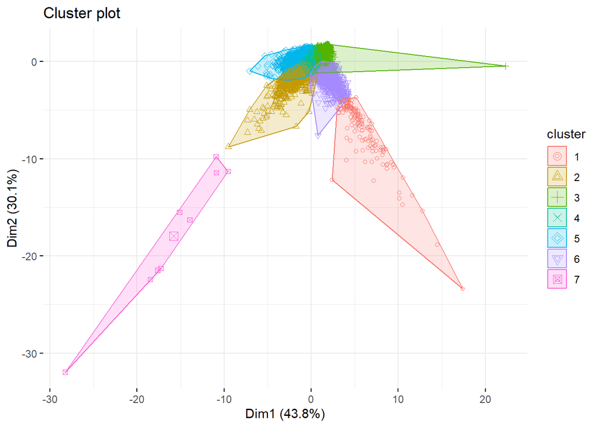

# Análisis de los clusters obtenidos

```
## # A tibble: 7 × 8
##   cluster_kmeans     n media_CO2 mediana_CO2 media_superficie mediana_superficie
##   <fct>          <int>     <dbl>       <dbl>            <dbl>              <dbl>
## 1 1                158      28.4        25.8           81856.              73375
## 2 2               2937      62.9        57              2509.               1860
## 3 3               7524      22.0        22              4296.               3360
## 4 4              15453      30.6        30.2            4400.               3624
## 5 5               5111      31.6        31              2678.               1880
## 6 6               2277      26.7        25.9           21727.              18940
## 7 7                  9     466.        427              2408.               2150
## # ℹ 2 more variables: media_antiguedad <dbl>, mediana_antiguedad <dbl>
```

```
## # A tibble: 7 × 10
##   cluster_kmeans `Centro de Enseñanza` Comercial `Cultural/Religioso` Deportivo
##   <fct>                          <int>     <int>                <int>     <int>
## 1 1                                  2       107                    1         2
## 2 2                                 11       563                   10         3
## 3 3                                 75      1707                   23        11
## 4 4                                 94      4616                   12         3
## 5 5                                 13      1138                    9         1
## 6 6                                 14      1515                    3         3
## 7 7                                  0         4                    0         0
## # ℹ 5 more variables: Hotel <int>, Industrial <int>, Otros <int>,
## #   Residencial <int>, Restaurante <int>
```

```
## # A tibble: 10 × 9
##    parcela_catastral EMISIONES_CO2_VALOR SUPERFICIE_M2 antiguedad   lat    lon
##    <chr>                           <dbl>         <dbl>      <dbl> <dbl>  <dbl>
##  1 000200100YJ28A                     48          6450        135  39.5 -0.409
##  2 000200200YJ26G                     34          2970         79  39.4 -0.430
##  3 000200400YJ27C                     26          7710         30  39.5 -0.408
##  4 000230300YJ16F                     56          1995         77  39.4 -0.490
##  5 000240800YJ06F                     53          1670         39  39.4 -0.472
##  6 000300600YJ26F                     28          6750         95  39.4 -0.362
##  7 000302100YJ26F                     49          2460         47  39.4 -0.352
##  8 000302300YJ26F                     49          1370         65  39.4 -0.357
##  9 000302300YJ26H                     29          2600        115  39.4 -0.361
## 10 000303500YJ26H                     31          2100        135  39.4 -0.357
## # ℹ 3 more variables: CODIGO_POSTAL <int>, uso_agregada <chr>,
## #   cluster_kmeans <fct>
```

GRUPO 2: Destacan los edificios de caracter residencial con una antigüedad de 57 años y un alto porcentaje de hoteles. Descatan también los restaurantes, todos estos tienen unas emisiones altas 62.94658 kg de CO2 por m2 al año, lo que es un comportamiento energético poco eficiente y seguramente sea debido a su antigüedad y a que no se han realizado reformas de mejora energética. En conclusión, Edificios algo antiguos con altas emisiones de CO2

GRUPO 3: Tienen emisiones bajas, tienen una antigüedad media de 25 años, se tratan de un buen porcentaje de los colegios centro deportivos, también destaca los colegios,viviendas y restaurantes. Por lo tanto, son edificios nuevos con emisiones bajas, hablamos de 22 kg por m2 al año.

GRUPO 4: Agrupa a la mayor cantidad de parcelas catastrales, hablamos de edificios de 58 años con emisiones en torno a la media sobre 30 . Pertenecen a este grupo gran parte de los comercios, industriales y los restautantes y los colegios y sibre todo residenciales. Edificios normales (lo habitual), emisiones medio-altas.

GRUPO 5: Un grupo bastante genérico con un comportamiento similar al grupo 4, pero con una antigüedad media de 100 años . Edificios viejos con emisiones medias.

GRUPo 6: Edificios que han realizado mejoras energéticas seguramente, esto se explica a su antigÜedad (43 años de media) y a sus bajas emisiones. Destacan comercios, y viviendas. Edificios reformados.

GRUPO 7: Casos extremos con emisiones muy por encima, tienen una media de 400 kg/m2 al año , se tratan de comercios y residenciales, tienen una antiguedad de 88 años.

En resumen:

🔹 Cluster 1: 🟨 “Grandes edificios recientes con eficiencia media”

🔹 Cluster 2: 🟥 “Edificios antiguos con alta ineficiencia”

🔹 Cluster 3: 🟩 “Edificios nuevos y diversos con alta eficiencia energética”

🔹 Cluster 5: ⬛ “Edificios muy antiguos con eficiencia moderada”

🔹 Cluster 6: 🟧 “Edificios reformados con buena eficiencia energética”

🔹 Cluster 7: 🟥 “Casos extremos de ineficiencia energética”

Como hemos podido identificar el comportamiento de los edificios vamos a proceder a realizar un clustering geográfico para ver si hay zonas homogéneas en cuanto a emisiones de CO2 y así poder relacionarlo con las zonas que estudian cada estación de contaminación.

### Mapa geográfico y la distribución de las coordenadas

Se agruparan los edificios en torno a las coordenadas de las estaciones de contaminación, para ver si hay zonas homogéneas en cuanto a emisiones de CO2 y así poder relacionarlo con los contaminantes. Se realizará un clustering basado en gemotría de Varonoi

```
## # A tibble: 6 × 9
##   parcela_catastral EMISIONES_CO2_VALOR SUPERFICIE_M2 antiguedad   lat   lon
##   <chr>                           <dbl>         <dbl>      <dbl> <dbl> <dbl>
## 1 000720100YJ16C                     26          5180         51   NaN   NaN
## 2 001430800YJ06F                     40          1720         40   NaN   NaN
## 3 001431900YJ06F                     45          1330         31   NaN   NaN
## 4 0036613YJ2703N                      8          4910          5   NaN   NaN
## 5 1449317YJ3514G                      9          1800          7   NaN   NaN
## 6 1776551YJ2717N                     35          1030         62   NaN   NaN
## # ℹ 3 more variables: CODIGO_POSTAL <int>, uso_agregada <chr>,
## #   cluster_kmeans <fct>
```

```
## [1] 82
```

```
## [1] 9
```

```
## # A tibble: 10 × 9
##    parcela_catastral EMISIONES_CO2_VALOR SUPERFICIE_M2 antiguedad   lat    lon
##    <chr>                           <dbl>         <dbl>      <dbl> <dbl>  <dbl>
##  1 000200100YJ28A                     48          6450        135  39.5 -0.409
##  2 000200200YJ26G                     34          2970         79  39.4 -0.430
##  3 000200400YJ27C                     26          7710         30  39.5 -0.408
##  4 000230300YJ16F                     56          1995         77  39.4 -0.490
##  5 000240800YJ06F                     53          1670         39  39.4 -0.472
##  6 000300600YJ26F                     28          6750         95  39.4 -0.362
##  7 000302100YJ26F                     49          2460         47  39.4 -0.352
##  8 000302300YJ26F                     49          1370         65  39.4 -0.357
##  9 000302300YJ26H                     29          2600        115  39.4 -0.361
## 10 000303500YJ26H                     31          2100        135  39.4 -0.357
## # ℹ 3 more variables: CODIGO_POSTAL <int>, uso_agregada <chr>,
## #   cluster_kmeans <fct>
```

Shiny applications not supported in static R Markdown documents

## CONCLUSIONES POR REGIONES

Se ha realizado un clustering geográfico de los edificios de Valencia, agrupando las coordenadas de los edificios en torno a las estaciones de contaminación.

1. Valencia- Pista de Silla Emisiones totales: 1.430.974 toneladas CO₂/año

Características: Esta región se presenta como el punto más crítico en cuanto a impacto climático. La gran mayoría de sus edificaciones son antiguas, con altos niveles de ineficiencia energética. A pesar de la presencia de algunos edificios reformados, el volumen global de construcciones con bajo rendimiento energético hace que las emisiones totales sean extremadamente elevadas.Tenemos que redordar que es la parte de más certificados se han presentado , por la gran presencia del mercado mobiliario o para mejorarlos eficentemente.

2. València - Molí del Sol Emisiones totales: 1.061.190 toneladas CO₂/año

Molí del Sol también destaca por un volumen de emisiones muy alto. La mayoría de los edificios son antiguos y carecen de actuaciones significativas de mejora energética. La baja proporción de edificaciones nuevas o reformadas evidencia una situación de estancamiento urbano.

3. Torrent - El Vedat Emisiones totales: 625.183 toneladas CO₂/año

Características: Se trata de una zona con un perfil mixto, en el que conviven edificios muy antiguos, construcciones comerciales y una cierta presencia de eficiencia media. Las emisiones son elevadas, aunque no extremas.

4.Valenica- Politecnic Emisiones totales: 615.600 toneladas de CO₂/año Esta zona, vinculada en parte al ámbito universitario y de servicios públicos, presenta una infraestructura antigua con bajo nivel de renovación. La eficiencia energética media es deficiente, y escasea la presencia de edificios nuevos .

5. Quart de Poblet Emisiones totales: 542.559 toneladas de CO₂/año Se observa una fuerte concentración de edificios antiguos, con pocos signos de mejora energética reciente. Aunque el volumen total de emisiones no es tan alto como en otras zonas, el perfil urbano muestra una eficiencia estancada.
6. València - Av. França Emisiones totales: 361.143 toneladas de CO₂/año Zona con un parque inmobiliario envejecido pero con una eficiencia que está en la media, también tiene un buen % de edificios nuevos o con grandes mejroas energéticas.
7. Massanassa Emisiones totales: 282.906 toneladas de CO₂/año Zona de carácter marcadamente comercial e industrial, donde predominan edificaciones de eficiencia energética media o baja, debido a que un % han sido reformados.
8. València Port Moll Transports Ponent Emisiones totales: 95.816,7 toneladas de CO₂/año

Predominan edificios antigüos uanque toma mucho peso también la parte de los reformados siendo muy eficientes. Los nivles de emisiones son moderados pero si se tuviera en cuenta otras acciones la zona de puerto debería de ser de los que más co2 emiten.

9. València Port llit antic Túria Emisiones totales: 80.123 toneladas de CO₂/año Zona histórica con baja densidad de emisiones. Pero es debido a la poca concentración de edificaciones residenciales, estas zonas realemente tienen muchas emisiones de CO2 por las combustiones genradas en el puerto pero en los CEE no se tienen en cuenta, los edificios de la zona puesto son solo almacenes con baja emisiones.

### Mapa estudio contaminación-CO2

Shiny applications not supported in static R Markdown documents

```
## # A tibble: 10 × 11
##    parcela_catastral EMISIONES_CO2_VALOR SUPERFICIE_M2 antiguedad   lat    lon
##    <chr>                           <dbl>         <dbl>      <dbl> <dbl>  <dbl>
##  1 000200100YJ28A                     48          6450        135  39.5 -0.409
##  2 000200200YJ26G                     34          2970         79  39.4 -0.430
##  3 000200400YJ27C                     26          7710         30  39.5 -0.408
##  4 000230300YJ16F                     56          1995         77  39.4 -0.490
##  5 000240800YJ06F                     53          1670         39  39.4 -0.472
##  6 000300600YJ26F                     28          6750         95  39.4 -0.362
##  7 000302100YJ26F                     49          2460         47  39.4 -0.352
##  8 000302300YJ26F                     49          1370         65  39.4 -0.357
##  9 000302300YJ26H                     29          2600        115  39.4 -0.361
## 10 000303500YJ26H                     31          2100        135  39.4 -0.357
## # ℹ 5 more variables: CODIGO_POSTAL <int>, uso_agregada <chr>,
## #   cluster_kmeans <fct>, clase_energetica <chr>, sensor_cercano <chr>
```

Al comparar con los certificados energéticos podemos observar discrepancias pero tienen sentido , de los cee solo hay de los diferentes edificios mientras que los sensores de contaminación miden el valor que hay en el aire en un momento dado, el co2 de los diferentes inmuebles se emite debido al uso de aparatos de refiregereacion y climatización, calentar el agua, cocinar por lo que los niveles más altos serán de 7-9 de la mañana (para calentar el agua), de 11 a 18 de la tarde en verano(aire acondicionados) y en inviertno de 19 a 23 horas por la calefacción.

Las emisiones de NO son superiores en la zona del puerto seguramente por las emisiones de los barcos, sin embargo edificio apenas emiten co2 pq no hay muchos por esta zona del casco antiguo si es una de los prinicpales emisoras de este gas y tambien de las zonas que más emiten co2 en la ciudad

Respecto al no2 vemos que es más emitido en feneral en toda la ciudad el puesto ya está solo, vemos zpoonas industriales como paterna y el casco por lo que podria tener relaci´pon con el co2

El o3 si que tiene un gran peso en Valenica excepto en la parte del puerto bajo.

El PM10 destaca en paterna , industias

# Calcular la matriz de dcorrelaciones person

```
##       Contaminante Pearson
## NO              NO  -0.310
## NO2            NO2  -0.133
## NOx            NOx  -0.232
## O3              O3   0.101
## PM10          PM10  -0.406
## PM2.5        PM2.5  -0.499
## SO2            SO2  -0.074
```

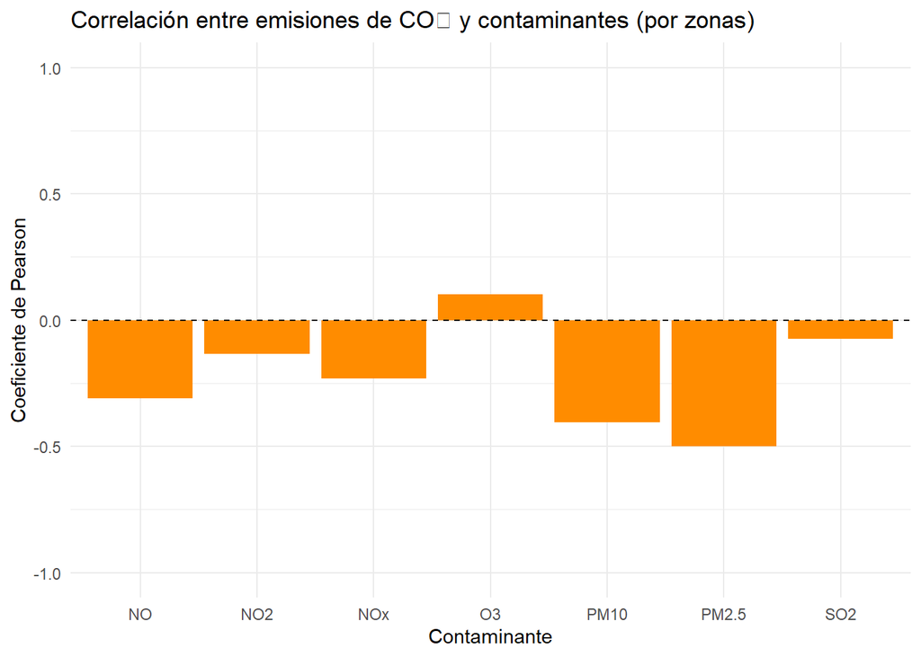

NO, NO2, NOx, PM10, PM2.5, SO2 → Tienen correlación negativa o casi nula con CO₂ → en zonas con más CO₂ (edificios grandes), no hay necesariamente más contaminantes. Puede ser que sean zonas más periféricas o industriales con menos densidad urbana.

El CO₂ no genera O₃ directamente, pero al contribuir al calentamiento y a la intensidad de la radiación UV, favorece las condiciones en las que el ozono troposférico se forma y acumula, especialmente en entornos urbanos soleados.

# Análisis contamianntes medias horarias verano e invierno

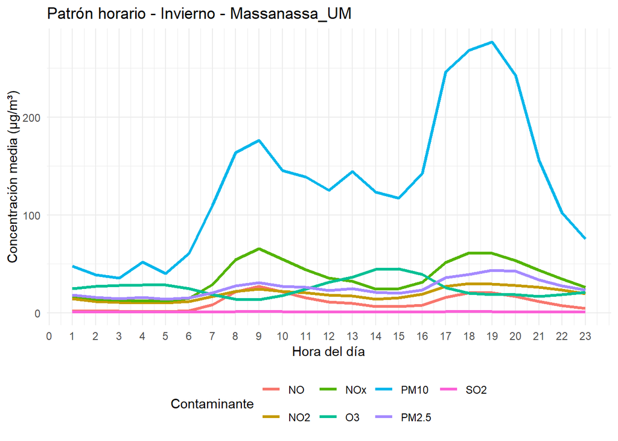

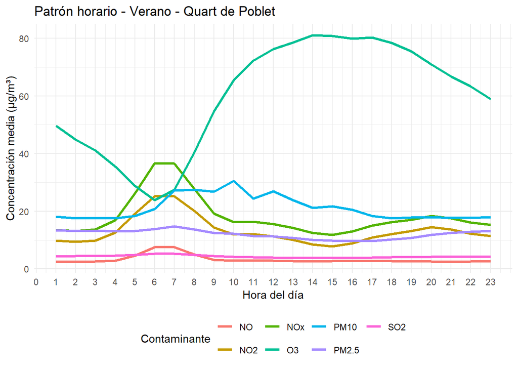

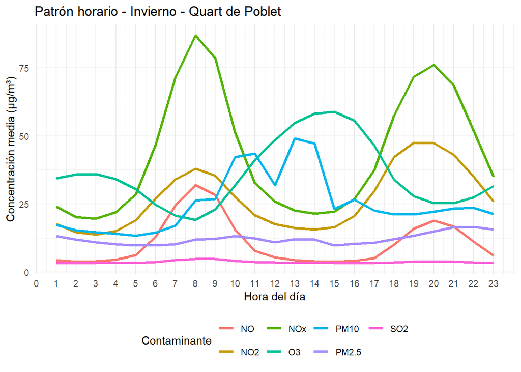

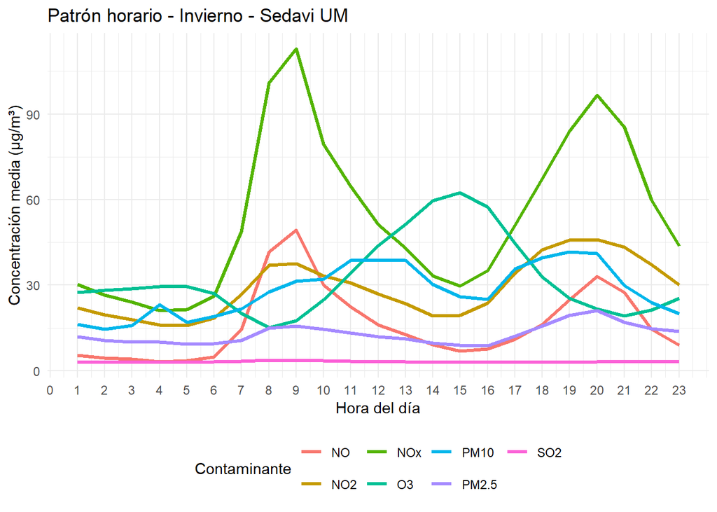